# Временные ряды

## неделя 5

Глазунов А.В.

Подключаем хранилище и загружаем нужные библиотеки

```python
from google.colab import drive
drive.mount('/content/gdrive',force_remount=True)
```

```
Go to this URL in a browser: https://accounts.google.com/o/oauth2/auth?client_id=947318989803-6bn6qk8qdgf4n4g3pfee6491hc0brc4i.apps.googleusercontent.com&redirect_uri=urn%3aietf%3awg%3aoauth%3a2.0%3aoob&response_type=code&scope=email%20https%3a%2f%2fwww.googleapis.com%2fauth%2fdocs.test%20https%3a%2…

Enter your authorization code:
··········
```

```python
cd /content/gdrive/'My Drive'/Colab_Notebooks/ML_c6_TAXI
```

```
/content/gdrive/My Drive/Colab_Notebooks/ML_c6_TAXI
```

```python
PATH_TO_DATA = 'data'
```

```python
pip install category_encoders
```

```
     |████████████████████████████████| 81kB 1.9MB/s
```

```python
pip install frozendict
```

```python
import warnings
warnings.filterwarnings('ignore')


from sklearn.base import BaseEstimator, TransformerMixin

from category_encoders import LeaveOneOutEncoder,TargetEncoder, BinaryEncoder,SumEncoder,BackwardDifferenceEncoder,HelmertEncoder
import os
import pandas as pd
import numpy as np
from frozendict import frozendict
from scipy import stats
from tqdm import tqdm_notebook
from matplotlib import pyplot as plt
import seaborn as sns
sns.set_style("darkgrid")
import gc
import xgboost as xgb
from sklearn.linear_model import SGDRegressor
from sklearn.ensemble import RandomForestRegressor
import itertools
from sklearn import model_selection, metrics, pipeline, preprocessing,impute
from sklearn.metrics import mean_absolute_error as mae
from sklearn.feature_selection import SelectFromModel, SelectKBest, mutual_info_regression,f_regression

from sklearn.preprocessing import PowerTransformer
from dateutil.relativedelta import relativedelta
```

Загружаем подготовленные данные

```python
datasets = []
for number in range(1,7):
  dataset = pd.read_csv(os.path.join(PATH_TO_DATA ,f'dataset{number}.csv'),index_col=0)
  dataset['datetime'] = pd.to_datetime(dataset['datetime'])
  datasets.append(dataset)
datasets[1].head()
```

|  | hour_counter | year | month | month_name | day_of_year | day_of_month | day_of_week | day_name | day_hour | zone_id | datetime | history_12 | history_24 | history_168 | history_720 | ts | srmx_forecast | target |
| --- | --- | --- | --- | --- | --- | --- | --- | --- | --- | --- | --- | --- | --- | --- | --- | --- | --- | --- |
| 0 | 1 | 2015 | 12 | December | 335 | 1 | 1 | Tuesday | 0 | 1075 | 2015-12-01 00:00:00 | 1031.269231 | 1385.807692 | 10552.346154 | 43939.576923 | 19 | 57.155572 | 8.0 |
| 1 | 2 | 2015 | 12 | December | 335 | 1 | 1 | Tuesday | 1 | 1075 | 2015-12-01 01:00:00 | 967.538462 | 1382.846154 | 10543.153846 | 43900.000000 | 16 | 57.516078 | 3.0 |
| 2 | 3 | 2015 | 12 | December | 335 | 1 | 1 | Tuesday | 2 | 1075 | 2015-12-01 02:00:00 | 887.346154 | 1379.730769 | 10535.269231 | 43872.423077 | 8 | 57.879168 | 2.0 |
| 3 | 4 | 2015 | 12 | December | 335 | 1 | 1 | Tuesday | 3 | 1075 | 2015-12-01 03:00:00 | 792.615385 | 1379.153846 | 10531.961538 | 43854.961538 | 3 | 58.244975 | 7.0 |
| 4 | 5 | 2015 | 12 | December | 335 | 1 | 1 | Tuesday | 4 | 1075 | 2015-12-01 04:00:00 | 699.884615 | 1379.884615 | 10532.576923 | 43844.884615 | 2 | 58.613734 | 20.0 |

Инициализируем необходимые функции и классы

```python
def harmonic_feats(data,kw=2,ky=0,linear_fe=False):
    #Гармонические признаки и тренды

    df = data.copy()
    zones_number = df.zone_id.unique().shape[0]
    arg = df.hour_counter.unique()
    fe_list = []
    columns = []

    #Линейный признак для описания простейшего тренда
    if linear_fe:
      fe_list.append(arg)
      columns.append('t')

    #Признаки для описания недельной сезонности
    for i in range(1,kw+1):
      fe_list.append(np.sin(arg*2*np.pi*i/168))
      columns.append(f'sin(2*pi*t*{i}/168)')
      fe_list.append(np.cos(arg*2*np.pi*i/168))
      columns.append(f'cos(2*pi*t*{i}/168)')

    #Признаки для описания годовой сезонности
    for j in range(1,ky+1):
      fe_list.append(np.sin(arg*2*np.pi*j/8766))
      columns.append(f'sin(2*pi*t*{j}/8766)')
      fe_list.append(np.cos(arg*2*np.pi*i/8766))
      columns.append(f'cos(2*pi*t*{j}/8766)')

    df = pd.DataFrame(fe_list).T
    df.columns = columns

    df_list = []
    for i in range(zones_number):
      df_list.append(df)

    return pd.concat(df_list,ignore_index=True)
```

```python
def find_mean_to_fill_empty(data):
  #Средние значения рядов по зонам для заполнения пропусков

  data = data.copy()
  ts_mean_values = {}
  for zone in tqdm_notebook(data.zone_id.unique()):
    data_zone = data[data['zone_id']==zone]
    ts_zone_means = []
    for day in range(7):
      for hour in range(0,24):
        ts_mean_day_hour_value = data_zone[data_zone['day_of_week']==day][data_zone['day_hour']==hour]['ts'].mean()
        ts_zone_means.append(ts_mean_day_hour_value)

    ts_mean_values[zone] = ts_zone_means
  return ts_mean_values
```

```python
def autoreg_feats(data,k,kd,fill_empty=False,ts_mean_values=None):
  #Авторегрессионные признаки

  df = data.copy()
  zone_list = df.zone_id.unique()
  #Цикл по зонам, запись в список
  zone_arfeats_list = []
  for zone in zone_list:
    df_zone = df[df.zone_id==zone].copy()
    df_zone.index = list(range(df_zone.shape[0]))
    ts_zone = df_zone.ts.values

    #Подготовка авторегрессионных признаков при смещении на 1..k часов назад
    feats_shift_hour = np.zeros((df_zone.shape[0],k))
    for i in range(df_zone.shape[0]):
      for j in range(k):
        shift = j+1
        if shift <= i:
          feats_shift_hour[i,j] = ts_zone[i-shift]
        elif fill_empty:#Заполнение недостающих значений средними
          shift = shift % 168
          means = ts_mean_values[zone]
          day = df_zone.day_of_week[i]
          hour = df_zone.day_hour[i]

          feats_shift_hour[i,j] = means[24*day + hour - shift]

    df_arfeats1 = pd.DataFrame(feats_shift_hour)
    df_arfeats1.columns = [f'ts_shift_{i}_hours' for i in range(1,k+1)]

    #Подготовка авторегрессионных признаков при смещении на 1..kd дней назад
    feats_shift_day = np.zeros((df_zone.shape[0],kd))

    for i in range(df_zone.shape[0]):
      for j in range(kd):
          shift = 24*(j+1)
          if  shift <= i:
            feats_shift_day[i,j] = ts_zone[i-shift]
          elif fill_empty:#Заполнение недостающих значений средними
            shift = shift % 168
            means = ts_mean_values[zone]
            day = df_zone.day_of_week[i]
            hour = df_zone.day_hour[i]
            feats_shift_day[i,j] = means[24*day + hour - shift]

    df_arfeats2 = pd.DataFrame(feats_shift_day)
    df_arfeats2.columns = [f'ts_shift_{i}_days' for i in range(1,kd+1)]

    df_arfeats_zone = pd.concat([df_arfeats1,df_arfeats2],axis=1)

    zone_arfeats_list.append(df_arfeats_zone)

  return pd.concat(zone_arfeats_list,ignore_index=True)
```

```python
def normed_fe_interaction(dataset,level=3, max_feats = 10):
  #Создает признаки на основе комбинаций существующих
  data = dataset.copy()

  fe_list = []

  for comb in list(itertools.combinations(data.columns,level))[:max_feats]:

    if level==2:
      a = (data[comb[0]] - data[comb[0]].mean())/data[comb[0]].std()
      b = (data[comb[1]] - data[comb[1]].mean())/data[comb[1]].std()
      feature = a*b
      feature.name = f'{comb[0]},{comb[1]}_mix'

    elif level==3:
      a = (data[comb[0]] - data[comb[0]].mean())/data[comb[0]].std()
      b = (data[comb[1]] - data[comb[1]].mean())/data[comb[1]].std()
      c = (data[comb[2]] - data[comb[2]].mean())/data[comb[2]].std()
      feature = a*b + a*c + b*c
      feature.name = f'{comb[0]},{comb[1]},{comb[2]}_mix'

    elif level==4:
      a = (data[comb[0]] - data[comb[0]].mean())/data[comb[0]].std()
      b = (data[comb[1]] - data[comb[1]].mean())/data[comb[1]].std()
      c = (data[comb[2]] - data[comb[2]].mean())/data[comb[2]].std()
      d = (data[comb[3]] - data[comb[3]].mean())/data[comb[3]].std()
      feature = a*b + a*c + a*d + b*d + b*c + c*d
      feature.name = f'{comb[0]},{comb[1]},{comb[2]},{comb[3]}_mix'

    elif level==5:
      a = (data[comb[0]] - data[comb[0]].mean())/data[comb[0]].std()
      b = (data[comb[1]] - data[comb[1]].mean())/data[comb[1]].std()
      c = (data[comb[2]] - data[comb[2]].mean())/data[comb[2]].std()
      d = (data[comb[3]] - data[comb[3]].mean())/data[comb[3]].std()
      e = (data[comb[4]] - data[comb[4]].mean())/data[comb[4]].std()
      feature = a*b + a*c + a*d +a*e + b*c + b*d + b*e + c*d + c*e + d*e
      feature.name = f'{comb[0]},{comb[1]},{comb[2]},{comb[3]},{comb[4]}_mix'

    fe_list.append(pd.DataFrame(feature))
  if fe_list==[]:
    features = pd.DataFrame()
  else:
    features = pd.concat(fe_list,axis=1)

  return features


def squared_feats(dataset):
  #Создает признаки-квадраты
  data = dataset.copy()

  fe_list = []
  for col in data.columns:
     feature = data[col]*data[col]
     feature.name = f'{col}**2'
     fe_list.append(pd.DataFrame(feature))

  if fe_list==[]:
    features = pd.DataFrame()
  else:
    features = pd.concat(fe_list,axis=1)

  return features

def cubic_feats(dataset):
  #Создает признаки-кубы
  data = dataset.copy()

  fe_list = []
  for col in data.columns:
     feature = data[col]*data[col]*data[col]
     feature.name = f'{col}**3'
     fe_list.append(pd.DataFrame(feature))

  if fe_list==[]:
    features = pd.DataFrame()
  else:
    features = pd.concat(fe_list,axis=1)

  return features
```

```python
def fe_transformer(num_indices,cat_indices,cat_transformer):
    return pipeline.FeatureUnion(transformer_list =[
    #numeric
    ('numeric_features_processing', pipeline.Pipeline(steps = [
    ('selecting', preprocessing.FunctionTransformer(lambda data: data[:, num_indices])),
                        ])),
    #categorical
    ('categorical_features_processing', pipeline.Pipeline(steps = [
    ('selecting', preprocessing.FunctionTransformer(lambda data: data[:, cat_indices])),
    ('cat_transformer', cat_transformer)
                        ]))
    ])
```

```python
class Estimator(BaseEstimator, TransformerMixin):

    def __init__(self, transformer,regressor):
        self.transformer = transformer
        self.regressor = regressor

    def fit(self, X, y):
        self.transformer.fit(X,y)
        X_tr = self.transformer.transform(X)
        self.regressor.fit(X_tr,y)
        return self.regressor

    def predict(self, X):
        X_tr = self.transformer.transform(X)
        return self.regressor.predict(X_tr)
```

```python
class EstimatorSelectorFromModel(BaseEstimator, TransformerMixin):

    def __init__(self, transformer,selecting_estimator,regressor):
        self.transformer = transformer
        self.selecting_estimator = selecting_estimator
        self.regressor = regressor

    def fit(self, X, y):
        self.transformer.fit(X,y)
        X_tr = self.transformer.transform(X)

        self.selecting_estimator.fit(X_tr,y)
        self.selecting_model = SelectFromModel(self.selecting_estimator, prefit=True)
        X_new = self.selecting_model.transform(X_tr)

        self.regressor.fit(X_new,y)
        return self.regressor

    def predict(self, X):
        X_tr = self.transformer.transform(X)
        X_new = self.selecting_model.transform(X_tr)
        return self.regressor.predict(X_new)
```

```python
ts_mean_values = find_mean_to_fill_empty(dataset[dataset.datetime < pd.to_datetime('2016-05-01 00:00:00')])
gc.collect()
```

```
3
```

```python
def error_estimation(data,params_prep,cols_to_mix_feats=[],cols_for_q=[],cols_for_c=[],
                     cat_encoder =TargetEncoder(),
                     train_lims = ['2015-12-01 00:00:00','2016-05-01 00:00:00'],
                     cols_to_drop=[],reg_algo=None,fill_empty=False,ts_mean_values=None,verbose=False,
                     show_fe_importances = False):
  dataset = data.copy()

  [k1,k2,k3,k4,k5,k6] = params_prep
  warnings.filterwarnings('ignore')
  if verbose:
    print('------------------')
    print(f'Solving with params{[k1,k2,k3,k4,k5,k6]}')
    print('------------------')
  harmonic_fe = harmonic_feats(dataset,kw=k1,ky=k2,linear_fe=False)

  autoreg_fe = autoreg_feats(dataset,k = k3 ,kd = k4,fill_empty=fill_empty,ts_mean_values=ts_mean_values)

  if verbose:
    print('------------------')
    print('creation harmonic_fe, autoreg_fe completed')
    print('------------------')

  dataset_mid = pd.concat([dataset,harmonic_fe,autoreg_fe],axis=1)



  mixed_feats = normed_fe_interaction(dataset_mid[cols_to_mix_feats],level=k5,max_feats = k6)
  squares = squared_feats(dataset_mid[cols_for_q])
  cubes = cubic_feats(dataset_mid[cols_for_c])
  deriv_feats = pd.concat([squares,cubes,mixed_feats],axis = 1)
  if verbose:
    print('------------------')
    print('creation deriv_feats completed')
    print('------------------')

  dataset_res = pd.concat([dataset_mid,deriv_feats],axis=1).drop(columns=cols_to_drop)

  dataset_train = dataset_res[dataset_res.datetime < pd.to_datetime(train_lims[1])][dataset_res.datetime \
                                                                                    >= pd.to_datetime(train_lims[0])].copy()
  dataset_val = dataset_res[dataset_res.datetime \
                            < pd.to_datetime('2016-06-01 00:00:00')][dataset_res.datetime >=
                                                                      pd.to_datetime('2016-05-01 00:00:00')].copy()
  if verbose:
    print('------------------')
    print('prep datasets completed')
    print('------------------')

  cat_cols = ['year','month_name','day_name', 'zone_id']
  cols_not_num = ['hour_counter','year','month_name','day_name','datetime','zone_id','target']
  num_indices = np.array([col not in cols_not_num for col in dataset_res.drop(columns=['target']).columns],dtype=bool)
  cat_indices = np.array([col in cat_cols for col in dataset_res.drop(columns=['target']).columns],dtype=bool)

  cat_transformer = cat_encoder

  gc.collect()

  if verbose:
    print('------------------')
    print('preproc completed')
    print('------------------')

  transformer =  fe_transformer(num_indices,cat_indices,cat_transformer)
  regressor =  reg_algo

  if verbose:
    print('------------------')
    print('fitting the model...')

  model = Estimator(transformer,regressor)
  model.fit(dataset_train.drop(columns=['target']).values,dataset_train.target.values)


  if verbose:
    print('------------------')
    print('model fitted')
    print('------------------')

    print('------------------')
    print('predicting and scoring...')
    print('------------------')

  prediction_val  = model.predict(dataset_val.drop(columns=['target']).values)
  error = mae(dataset_val.target,prediction_val)

  if verbose:
    print(f'params[k1,k2,k3,k4,k5,k6]: {[k1,k2,k3,k4,k5,k6]},mean absolute error: {error}')
    print('------------------')
    print('------------------')

  if show_fe_importances:
    plt.figure(figsize=(20,50))

    feature_importances = model.regressor.feature_importances_


    num_names = np.array(dataset_train.drop(columns=['target']).columns)[num_indices]
    cat_names = np.array(dataset_train.drop(columns=['target']).columns)[cat_indices]
    fe_names = np.hstack([num_names,cat_names])
    plt.barh(fe_names, feature_importances)
    plt.title('Feature importances')
    plt.xticks(rotation=90)

  gc.collect()
  return error
```

В предварительном тестировании градиентный бустинг показал себя лучше других алгоритмов, поэтому построим бейзлайн на нём. Также вручную подберем признаки для смешивания и для удаления на основе feature_importances. Будем рассматривать 2 модели, одна для предсказания на 1 час вперед, другая для остальных, поскольку на этапе предварительного тестирования оказалось, что последние 5 задач схожи по решению.

```
------------------
Solving with params[0, 0, 2, 2, 4, 23]
------------------
------------------
creation harmonic_fe, autoreg_fe completed
------------------
------------------
creation deriv_feats completed
------------------
------------------
prep datasets completed
------------------
------------------
preproc completed
------------------
------------------
fitting the model...
------------------
model fitted
------------------
------------------
predicting and scoring...
------------------
params[k1,k2,k3,k4,k5,k6]: [0, 0, 2, 2, 4, 23],mean absolute error: 26.44387074801682
------------------
------------------
CPU times: user 18.6 s, sys: 547 ms, total: 19.2 s
Wall time: 19.3 s
```

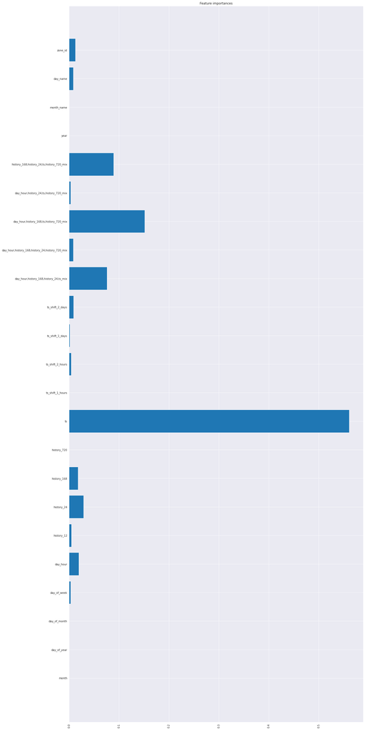

```python
%%time
dataset = datasets[0].copy()
regressor = xgb.XGBRegressor(random_state=42,n_estimators=50,objective='reg:squarederror')
cols = ['day_hour','history_168','history_24','ts','history_720']
error0 = error_estimation(dataset, params_prep = [0,0,2,2,4,23],
                 fill_empty = False,ts_mean_values=None,
                 cat_encoder = TargetEncoder(),
                 cols_to_drop=['srmx_forecast'],
                 cols_to_mix_feats = cols ,
                 cols_for_q=[],cols_for_c = [],
                 train_lims = ['2016-02-01 00:00:00','2016-05-01 00:00:00'],
                 reg_algo = regressor,
                 verbose=True,
                 show_fe_importances=True
                 )
gc.collect()
```

```
------------------
Solving with params[2, 0, 4, 2, 2, 23]
------------------
------------------
creation harmonic_fe, autoreg_fe completed
------------------
------------------
creation deriv_feats completed
------------------
------------------
prep datasets completed
------------------
------------------
preproc completed
------------------
------------------
fitting the model...
------------------
model fitted
------------------
------------------
predicting and scoring...
------------------
params[k1,k2,k3,k4,k5,k6]: [2, 0, 4, 2, 2, 23],mean absolute error: 32.818371092722735
------------------
------------------
CPU times: user 29.6 s, sys: 591 ms, total: 30.2 s
Wall time: 30.1 s
```

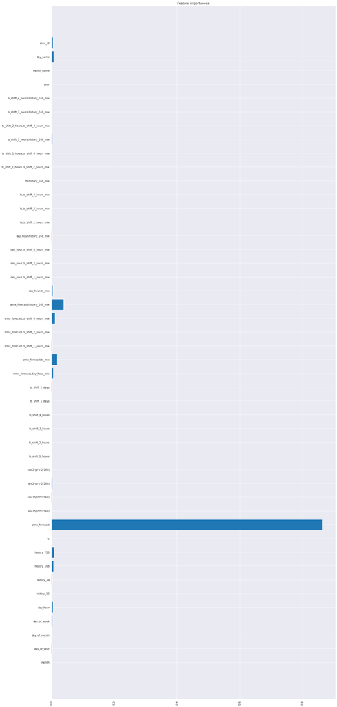

```python
%%time
dataset = datasets[5].copy()
regressor = xgb.XGBRegressor(random_state=42,n_estimators=50,objective='reg:squarederror')
cols = ['srmx_forecast','day_hour','ts','ts_shift_1_hours','ts_shift_2_hours','ts_shift_4_hours','history_168']
error0 = error_estimation(dataset, params_prep = [2,0,4,2,2,23],
                 fill_empty = False,ts_mean_values=None,
                 cat_encoder = TargetEncoder(),
                 cols_to_drop=[],
                 cols_to_mix_feats = cols ,
                 cols_for_q=[],cols_for_c = [],
                 train_lims = ['2016-02-01 00:00:00','2016-05-01 00:00:00'],
                 reg_algo = regressor,
                 verbose=True,
                 show_fe_importances=True
                 )
gc.collect()
```

Создадим функцию для подбора параметров алгоритма и подберем гиперпараметры

```python
def time_cross_validation(dataset,params_prep,starts,ends,algo,param_grid_regression,cols_to_mix,cols_to_drop):
  #Кросс-валидация по времени

  dataset = dataset.copy()

  param_names = list(param_grid_regression.keys())
  iterables=[['-'],['-'],['-'],['-']]
  for (i,key) in enumerate(param_names):
    iterables[i] = param_grid_regression[key]


  cv_scores = {}
  for reg_params in tqdm_notebook(list(itertools.product(iterables[0],iterables[1],iterables[2],iterables[3]))):

    regressor = algo
    param_dict={}
    for (ind,param) in enumerate(reg_params):
      if param != '-':
        name = param_names[ind]
        param_dict[name]  = param

    regressor.set_params(**param_dict)

    errors = []
    for (start,end) in zip(starts,ends):
      error = error_estimation(dataset, params_prep = params_prep,
                 cols_to_drop = cols_to_drop,
                 cols_to_mix_feats = cols_to_mix,
                 train_lims = [start,end],
                 reg_algo = regressor
                 )
      errors.append(error)

    cv_scores[frozendict(param_dict)] = errors
  return cv_scores
```

```python
%%time
starts =['2016-01-01 00:00:00','2016-02-01 00:00:00','2016-03-01 00:00:00','2016-04-01 00:00:00']
ends =['2016-02-01 00:00:00','2016-03-01 00:00:00','2016-04-01 00:00:00','2016-05-01 00:00:00']
regressor = xgb.XGBRegressor(random_state=42,n_estimators=50,objective='reg:squarederror')
param_grid_regression = {'gamma':[0,0.1,0.5],
                        'max_depth':[3,5,7],
                        'reg_alpha':[0,0.5,1]
                         }

cols_to_mix = ['day_hour','history_168','history_24','ts','history_720']
cols_to_drop = ['srmx_forecast']
params_prep=[0,0,2,2,4,23]
cv_scores1 = time_cross_validation(dataset = datasets[0],params_prep = params_prep,
                      starts=starts,ends=ends,
                      algo=regressor,
                      param_grid_regression = param_grid_regression,
                      cols_to_mix = cols_to_mix,
                      cols_to_drop = cols_to_drop)
cv_scores1
```

```
CPU times: user 18min 20s, sys: 9.46 s, total: 18min 29s
Wall time: 18min 23s
```

```python
cv_scores1
```

```
{<frozendict {'gamma': 0, 'max_depth': 3, 'reg_alpha': 0.5}>: [26.577663235019184,
  26.459035220041308,
  26.45898296239631,
  26.368688325790973],
 <frozendict {'gamma': 0, 'max_depth': 3, 'reg_alpha': 0}>: [26.577643325949378,
  26.459015510904056,
  26.45896198116549,
  26.36866249906886],
 <frozendict {'gamma': 0, 'max_depth': 3, 'reg_alpha': 1}>: [26.57768336221522,
  26.459054662405993,
  26.459003583316232,
  26.368712416519955],
 <frozendict {'gamma': 0, 'max_depth': 5, 'reg_alpha': 0.5}>: [22.493277062918192,
  22.199670858731075,
  22.17708431946158,
  21.894633395787018],
 <frozendict {'gamma': 0, 'max_depth': 5, 'reg_alpha': 0}>: [22.493235278373923,
  22.19959645037526,
  22.177022364794038,
  21.894540817165584],
 <frozendict {'gamma': 0, 'max_depth': 5, 'reg_alpha': 1}>: [22.493317049648592,
  22.19974563823121,
  22.17714859186447,
  21.894726378190104],
 <frozendict {'gamma': 0, 'max_depth': 7, 'reg_alpha': 0.5}>: [20.15463572360643,
  19.951551486340403,
  19.697075141916233,
  19.1513099768471],
 <frozendict {'gamma': 0, 'max_depth': 7, 'reg_alpha': 0}>: [20.090480462549205,
  19.93956481198121,
  19.63368356181024,
  19.217520465900375],
 <frozendict {'gamma': 0, 'max_depth': 7, 'reg_alpha': 1}>: [20.190306593825593,
  19.825062764431138,
  19.60110129033956,
  19.186223946139453],
 <frozendict {'gamma': 0.1, 'max_depth': 3, 'reg_alpha': 0.5}>: [26.577663235019184,
  26.459035220041308,
  26.45898296239631,
  26.368688325790973],
```

[output cut: 53 more lines]

```
  22.19974563823121,
  22.17714859186447,
  21.894726378190104],
 <frozendict {'gamma': 0.5, 'max_depth': 7, 'reg_alpha': 0.5}>: [20.15463572360643,
  19.951551486340403,
  19.697075141916233,
  19.1513099768471],
 <frozendict {'gamma': 0.5, 'max_depth': 7, 'reg_alpha': 0}>: [20.090480462549205,
  19.93956481198121,
  19.63368365127886,
  19.217520465900375],
 <frozendict {'gamma': 0.5, 'max_depth': 7, 'reg_alpha': 1}>: [20.190306593825593,
  19.825062764431138,
  19.601100955354045,
  19.186223946139453]}
```

```python
%%time
starts =['2016-01-01 00:00:00','2016-02-01 00:00:00','2016-03-01 00:00:00','2016-04-01 00:00:00']
ends =['2016-02-01 00:00:00','2016-03-01 00:00:00','2016-04-01 00:00:00','2016-05-01 00:00:00']
regressor = xgb.XGBRegressor(random_state=42,max_depth=7,n_estimators=50,objective='reg:squarederror')
param_grid_regression2 = {'subsample':[0.5,0.8,1],
                      'colsample_bytree':[0.5,0.8,1],
                      'min_child_weight':[1,3,5]
                      }
cols_to_mix = ['day_hour','history_168','history_24','ts','history_720']
cols_to_drop = ['srmx_forecast']
params_prep=[0,0,2,2,4,23]
cv_scores2 = time_cross_validation(dataset = datasets[0],params_prep = params_prep,
                      starts=starts,ends=ends,
                      algo=regressor,
                      param_grid_regression = param_grid_regression2,
                      cols_to_mix = cols_to_mix,
                      cols_to_drop = cols_to_drop)
cv_scores2
```

```
CPU times: user 21min 27s, sys: 7.25 s, total: 21min 34s
Wall time: 21min 28s
```

```python
cv_scores2
```

```
{<frozendict {'subsample': 0.5, 'colsample_bytree': 0.5, 'min_child_weight': 1}>: [21.49856677382435,
  20.72854601033032,
  20.598483582532484,
  20.303022661545413],
 <frozendict {'subsample': 0.5, 'colsample_bytree': 0.5, 'min_child_weight': 3}>: [21.453122841875633,
  20.566328428644823,
  20.541887053358618,
  20.353162653701414],
 <frozendict {'subsample': 0.5, 'colsample_bytree': 0.5, 'min_child_weight': 5}>: [21.328768710702604,
  20.457481234092693,
  20.653731572974866,
  20.25080858145617],
 <frozendict {'subsample': 0.5, 'colsample_bytree': 0.8, 'min_child_weight': 1}>: [20.60326295856158,
  20.133665837005847,
  20.090561536051005,
  19.370062032705846],
 <frozendict {'subsample': 0.5, 'colsample_bytree': 0.8, 'min_child_weight': 3}>: [20.501088891095506,
  20.119302040393652,
  20.126547499720242,
  19.36313570312207],
 <frozendict {'subsample': 0.5, 'colsample_bytree': 0.8, 'min_child_weight': 5}>: [20.537094928541393,
  20.17290527224753,
  20.012789523146534,
  19.261682497392833],
 <frozendict {'subsample': 0.5, 'colsample_bytree': 1, 'min_child_weight': 1}>: [20.412878808944605,
  19.919149227052355,
  20.05800356639888,
  19.424260715791224],
 <frozendict {'subsample': 0.5, 'colsample_bytree': 1, 'min_child_weight': 3}>: [20.357359918213763,
  19.864649639738442,
  20.13185669843366,
  19.386953941274427],
 <frozendict {'subsample': 0.5, 'colsample_bytree': 1, 'min_child_weight': 5}>: [20.308008597685006,
  19.90439222600832,
  20.101281646291163,
  19.314731662757985],
 <frozendict {'subsample': 0.8, 'colsample_bytree': 0.5, 'min_child_weight': 1}>: [21.28269486701351,
  20.39283340570664,
  20.46495179982941,
  20.215432077255898],
```

[output cut: 53 more lines]

```
  19.859005007374073,
  19.818102702207828,
  19.126097908079384],
 <frozendict {'subsample': 1, 'colsample_bytree': 1, 'min_child_weight': 1}>: [20.090480462549205,
  19.93956481198121,
  19.63368356181024,
  19.217520465900375],
 <frozendict {'subsample': 1, 'colsample_bytree': 1, 'min_child_weight': 3}>: [20.13087728031446,
  19.92772973806016,
  19.76479280964027,
  19.23787924456904],
 <frozendict {'subsample': 1, 'colsample_bytree': 1, 'min_child_weight': 5}>: [20.210753507363144,
  19.79745305806356,
  19.758367016726933,
  19.172529254548508]}
```

```python
%%time
starts =['2016-01-01 00:00:00','2016-02-01 00:00:00','2016-03-01 00:00:00','2016-04-01 00:00:00']
ends =['2016-02-01 00:00:00','2016-03-01 00:00:00','2016-04-01 00:00:00','2016-05-01 00:00:00']
regressor = xgb.XGBRegressor(random_state=42,max_depth=7,n_estimators=50,objective='reg:squarederror')
param_grid_regression3 = {'learning_rate':[0.01,0.02,0.05,0.08,0.1,0.2,0.3,0.4,0.5,0.6,0.8]
                          }
cols_to_mix = ['day_hour','history_168','history_24','ts','history_720']
cols_to_drop = ['srmx_forecast']
params_prep=[0,0,2,2,4,23]
cv_scores3 = time_cross_validation(dataset = datasets[0],params_prep = params_prep,
                      starts=starts,ends=ends,
                      algo=regressor,
                      param_grid_regression = param_grid_regression3,
                      cols_to_mix = cols_to_mix,
                      cols_to_drop = cols_to_drop)
cv_scores3
```

```
CPU times: user 9min 34s, sys: 2.13 s, total: 9min 36s
Wall time: 9min 34s
```

```python
cv_scores3
```

```
{<frozendict {'learning_rate': 0.01}>: [91.40123533754881,
  91.70614930086313,
  91.7569050864689,
  91.48793711424999],
 <frozendict {'learning_rate': 0.02}>: [56.257648606842174,
  56.68883587977641,
  56.93980767640878,
  56.41969122149045],
 <frozendict {'learning_rate': 0.05}>: [23.385689725921473,
  23.229177844716343,
  23.480478336259758,
  22.94382665885348],
 <frozendict {'learning_rate': 0.08}>: [20.611376858659792,
  20.23078959613085,
  20.147612936669088,
  19.5853741500584],
 <frozendict {'learning_rate': 0.1}>: [20.090480462549205,
  19.93956481198121,
  19.63368356181024,
  19.217520465900375],
 <frozendict {'learning_rate': 0.2}>: [19.95407323275196,
  19.445824033983058,
  19.162979202235448,
  18.713755721608837],
 <frozendict {'learning_rate': 0.3}>: [20.124219858035957,
  19.93386702973929,
  19.144950760050904,
  18.87219942994565],
 <frozendict {'learning_rate': 0.4}>: [20.568162908947247,
  20.49809515086065,
  19.505121003063923,
  19.039678428996762],
 <frozendict {'learning_rate': 0.5}>: [20.633749626963333,
  20.785617709182628,
  19.77800476980018,
  19.547788260416244],
 <frozendict {'learning_rate': 0.6}>: [21.656440987541718,
  21.520624824739315,
  20.32398505320868,
  19.78265949601322],
 <frozendict {'learning_rate': 0.8}>: [23.53358783237927,
  23.254223918391464,
  21.522688335495396,
  20.972909191777273]}
```

Лучшая модель с эмпирически подобранным числом деревьев

```
------------------
Solving with params[0, 0, 2, 2, 4, 23]
------------------
------------------
creation harmonic_fe, autoreg_fe completed
------------------
------------------
creation deriv_feats completed
------------------
------------------
prep datasets completed
------------------
------------------
preproc completed
------------------
------------------
fitting the model...
------------------
model fitted
------------------
------------------
predicting and scoring...
------------------
params[k1,k2,k3,k4,k5,k6]: [0, 0, 2, 2, 4, 23],mean absolute error: 16.816150795052586
------------------
------------------
CPU times: user 9min 26s, sys: 361 ms, total: 9min 27s
Wall time: 9min 27s
```

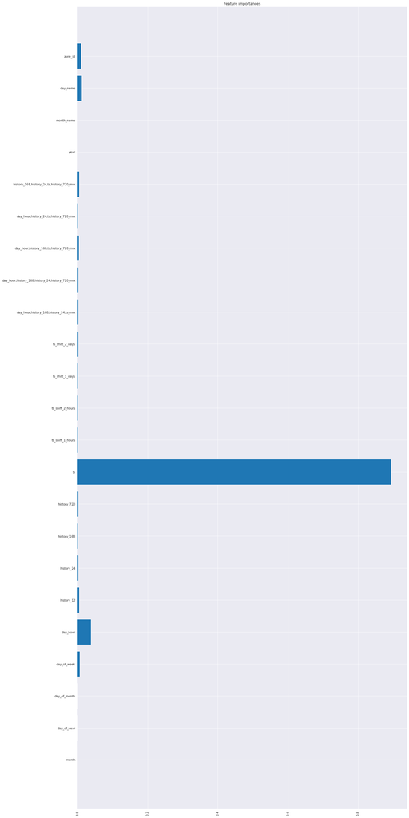

```python
%%time
dataset = datasets[0].copy()
regressor = xgb.XGBRegressor(random_state=42,max_depth=7, learning_rate=0.2,n_estimators=1000,objective='reg:squarederror')
cols = ['day_hour','history_168','history_24','ts','history_720']
error0 = error_estimation(dataset, params_prep = [0,0,2,2,4,23],
                 fill_empty = False,ts_mean_values=None,
                 cat_encoder = TargetEncoder(),
                 cols_to_drop=['srmx_forecast'],
                 cols_to_mix_feats = cols ,
                 cols_for_q=[],cols_for_c = [],
                 train_lims = ['2016-02-01 00:00:00','2016-05-01 00:00:00'],
                 reg_algo = regressor,
                 verbose=True,
                 show_fe_importances=True
                 )
gc.collect()
```

```python
%%time
starts =['2016-01-01 00:00:00','2016-02-01 00:00:00','2016-03-01 00:00:00','2016-04-01 00:00:00']
ends =['2016-02-01 00:00:00','2016-03-01 00:00:00','2016-04-01 00:00:00','2016-05-01 00:00:00']
regressor = xgb.XGBRegressor(random_state=42,n_estimators=50,objective='reg:squarederror')
param_grid_regression = {'gamma':[0,0.1,0.5],
                        'max_depth':[3,5,7],
                        'reg_alpha':[0,0.5,1]
                         }

cols_to_mix = ['srmx_forecast','day_hour','ts','ts_shift_1_hours','ts_shift_2_hours','ts_shift_4_hours','history_168']
cols_to_drop = []
params_prep= [2,0,4,2,2,23]
cv_scores1 = time_cross_validation(dataset = datasets[5],params_prep = params_prep,
                      starts=starts,ends=ends,
                      algo=regressor,
                      param_grid_regression = param_grid_regression,
                      cols_to_mix = cols_to_mix,
                      cols_to_drop = cols_to_drop)
cv_scores1
```

```
CPU times: user 32min 1s, sys: 9.58 s, total: 32min 11s
Wall time: 32min 3s
```

```python
cv_scores1
```

```
{<frozendict {'gamma': 0, 'max_depth': 3, 'reg_alpha': 0.5}>: [32.820546450891776,
  32.81656922955767,
  33.00082988582273,
  32.93852102772837],
 <frozendict {'gamma': 0, 'max_depth': 3, 'reg_alpha': 0}>: [32.820527643989514,
  32.816558044293046,
  33.00081984188086,
  32.93850993706711],
 <frozendict {'gamma': 0, 'max_depth': 3, 'reg_alpha': 1}>: [32.81517655592339,
  32.81658016166279,
  33.06313993652209,
  32.93853174484583],
 <frozendict {'gamma': 0, 'max_depth': 5, 'reg_alpha': 0.5}>: [31.517035506455212,
  31.38826722093123,
  31.89922089425165,
  32.019392525211316],
 <frozendict {'gamma': 0, 'max_depth': 5, 'reg_alpha': 0}>: [31.54461427494387,
  31.39447025772661,
  31.872056236560905,
  32.080665866383896],
 <frozendict {'gamma': 0, 'max_depth': 5, 'reg_alpha': 1}>: [31.576608633511388,
  31.303023681453002,
  31.841798881507486,
  32.02002645013436],
 <frozendict {'gamma': 0, 'max_depth': 7, 'reg_alpha': 0.5}>: [30.918383864112137,
  30.5281331843445,
  30.705047355041508,
  31.372566893899034],
 <frozendict {'gamma': 0, 'max_depth': 7, 'reg_alpha': 0}>: [30.86992617389578,
  30.440159509701868,
  30.774384791975958,
  31.410585718766253],
 <frozendict {'gamma': 0, 'max_depth': 7, 'reg_alpha': 1}>: [30.98322634292119,
  30.49497421435861,
  30.745649491521018,
  31.276573299984236],
 <frozendict {'gamma': 0.1, 'max_depth': 3, 'reg_alpha': 0.5}>: [32.820546450891776,
  32.81656922955767,
  33.00082988582273,
  32.93852102772837],
```

[output cut: 53 more lines]

```
  31.303023681453002,
  31.841798881507486,
  32.02002645013436],
 <frozendict {'gamma': 0.5, 'max_depth': 7, 'reg_alpha': 0.5}>: [30.918383864112137,
  30.5281331843445,
  30.73719377706431,
  31.372566893899034],
 <frozendict {'gamma': 0.5, 'max_depth': 7, 'reg_alpha': 0}>: [30.869952664629093,
  30.440159509701868,
  30.774385925155386,
  31.410585718766253],
 <frozendict {'gamma': 0.5, 'max_depth': 7, 'reg_alpha': 1}>: [30.98322634292119,
  30.49497421435861,
  30.745649698456454,
  31.276573299984236]}
```

```python
%%time
starts =['2016-01-01 00:00:00','2016-02-01 00:00:00','2016-03-01 00:00:00','2016-04-01 00:00:00']
ends =['2016-02-01 00:00:00','2016-03-01 00:00:00','2016-04-01 00:00:00','2016-05-01 00:00:00']
regressor = xgb.XGBRegressor(random_state=42,max_depth=7,n_estimators=50,objective='reg:squarederror')
param_grid_regression2 = {'subsample':[0.5,0.8,1],
                      'colsample_bytree':[0.5,0.8,1],
                      'min_child_weight':[1,3,5]
                      }
cols_to_mix = ['srmx_forecast','day_hour','ts','ts_shift_1_hours','ts_shift_2_hours','ts_shift_4_hours','history_168']
cols_to_drop = []
params_prep= [2,0,4,2,2,23]
cv_scores2 = time_cross_validation(dataset = datasets[5],params_prep = params_prep,
                      starts=starts,ends=ends,
                      algo=regressor,
                      param_grid_regression = param_grid_regression2,
                      cols_to_mix = cols_to_mix,
                      cols_to_drop = cols_to_drop)
cv_scores2
```

```
CPU times: user 36min 51s, sys: 8.2 s, total: 36min 59s
Wall time: 36min 52s
```

```python
cv_scores2
```

```
{<frozendict {'subsample': 0.5, 'colsample_bytree': 0.5, 'min_child_weight': 1}>: [31.483446489501176,
  30.578713504132963,
  30.898271340835976,
  31.123531770309064],
 <frozendict {'subsample': 0.5, 'colsample_bytree': 0.5, 'min_child_weight': 3}>: [31.47161437269012,
  30.653325209959213,
  31.018587711120887,
  31.298274198617694],
 <frozendict {'subsample': 0.5, 'colsample_bytree': 0.5, 'min_child_weight': 5}>: [31.377076717812646,
  30.5655320237634,
  30.944962601081375,
  31.25358281853614],
 <frozendict {'subsample': 0.5, 'colsample_bytree': 0.8, 'min_child_weight': 1}>: [31.17723050007517,
  30.623603757787766,
  30.976163961741804,
  31.741587957952838],
 <frozendict {'subsample': 0.5, 'colsample_bytree': 0.8, 'min_child_weight': 3}>: [31.355675225315178,
  30.540340874217655,
  30.917290481335623,
  31.613369463278275],
 <frozendict {'subsample': 0.5, 'colsample_bytree': 0.8, 'min_child_weight': 5}>: [31.278682613388746,
  30.644542862336603,
  30.95594270222852,
  31.34735582343136],
 <frozendict {'subsample': 0.5, 'colsample_bytree': 1, 'min_child_weight': 1}>: [31.02358674145913,
  30.579897962102162,
  30.882070337679224,
  31.640493196927935],
 <frozendict {'subsample': 0.5, 'colsample_bytree': 1, 'min_child_weight': 3}>: [31.080516391258822,
  30.49747305875202,
  30.98880374132676,
  31.68417299578554],
 <frozendict {'subsample': 0.5, 'colsample_bytree': 1, 'min_child_weight': 5}>: [31.239772659380264,
  30.523692391614873,
  31.03060192367148,
  31.58358287584565],
 <frozendict {'subsample': 0.8, 'colsample_bytree': 0.5, 'min_child_weight': 1}>: [31.33696074486949,
  30.31613277418383,
  30.712904476157924,
  30.83379462999379],
```

[output cut: 53 more lines]

```
  30.307324723327415,
  30.70126590818393,
  31.46560248848496],
 <frozendict {'subsample': 1, 'colsample_bytree': 1, 'min_child_weight': 1}>: [30.86992617389578,
  30.440159509701868,
  30.774384791975958,
  31.410585718766253],
 <frozendict {'subsample': 1, 'colsample_bytree': 1, 'min_child_weight': 3}>: [31.12245301502275,
  30.4082727787477,
  30.80521239806222,
  31.550229979421367],
 <frozendict {'subsample': 1, 'colsample_bytree': 1, 'min_child_weight': 5}>: [31.02014995024202,
  30.30652206072212,
  30.742706413538478,
  31.415400279247194]}
```

```python
%%time
starts =['2016-01-01 00:00:00','2016-02-01 00:00:00','2016-03-01 00:00:00','2016-04-01 00:00:00']
ends =['2016-02-01 00:00:00','2016-03-01 00:00:00','2016-04-01 00:00:00','2016-05-01 00:00:00']
regressor = xgb.XGBRegressor(random_state=42,max_depth=7,colsample_bytree= 0.5, min_child_weight= 3,n_estimators=50,objective='reg:squarederror')
param_grid_regression3 = {'learning_rate':[0.01,0.02,0.05,0.08,0.1,0.2,0.3,0.4,0.5,0.6,0.8]
                          }
cols_to_mix = ['srmx_forecast','day_hour','ts','ts_shift_1_hours','ts_shift_2_hours','ts_shift_4_hours','history_168']
cols_to_drop = []
params_prep= [2,0,4,2,2,23]
cv_scores3 = time_cross_validation(dataset = datasets[5],params_prep = params_prep,
                      starts=starts,ends=ends,
                      algo=regressor,
                      param_grid_regression = param_grid_regression3,
                      cols_to_mix = cols_to_mix,
                      cols_to_drop = cols_to_drop)
cv_scores3
```

```
CPU times: user 11min 40s, sys: 2.97 s, total: 11min 42s
Wall time: 11min 40s
```

```python
cv_scores3
```

```
{<frozendict {'learning_rate': 0.01}>: [90.76050845094711,
  90.52734409476096,
  91.06343157706779,
  90.67689659679907],
 <frozendict {'learning_rate': 0.02}>: [58.44514885375124,
  58.24681624887037,
  58.93872081778194,
  58.46080828458856],
 <frozendict {'learning_rate': 0.05}>: [32.70263387578328,
  32.444865287299045,
  32.91615165028138,
  32.759495413128384],
 <frozendict {'learning_rate': 0.08}>: [31.17056448244881,
  30.44185921308749,
  30.74567234476558,
  30.994874214608597],
 <frozendict {'learning_rate': 0.1}>: [31.09580544178515,
  30.204977126551338,
  30.371449948595405,
  30.600884838061553],
 <frozendict {'learning_rate': 0.2}>: [30.98700533595958,
  29.969352487283036,
  30.346934991305325,
  30.48466451735093],
 <frozendict {'learning_rate': 0.3}>: [31.536424694023594,
  30.511410577684536,
  30.50026157039237,
  30.97498799576702],
 <frozendict {'learning_rate': 0.4}>: [32.81053718518927,
  30.488118181811362,
  31.118430060857403,
  31.478817268037723],
 <frozendict {'learning_rate': 0.5}>: [32.670389999532034,
  31.177244877412477,
  31.0937545140622,
  31.57862962144536],
 <frozendict {'learning_rate': 0.6}>: [33.38666814888666,
  32.12942605337979,
  32.06260942891492,
  32.63050456945346],
 <frozendict {'learning_rate': 0.8}>: [36.329332503566924,
  33.21180160641482,
  34.0369168228662,
  34.038447136548726]}
```

Лучшая модель с эмпирически подобранным числом деревьев.

```
------------------
Solving with params[2, 0, 4, 2, 2, 23]
------------------
------------------
creation harmonic_fe, autoreg_fe completed
------------------
------------------
creation deriv_feats completed
------------------
------------------
prep datasets completed
------------------
------------------
preproc completed
------------------
------------------
fitting the model...
------------------
model fitted
------------------
------------------
predicting and scoring...
------------------
params[k1,k2,k3,k4,k5,k6]: [2, 0, 4, 2, 2, 23],mean absolute error: 28.06457559636753
------------------
------------------
CPU times: user 8min 32s, sys: 438 ms, total: 8min 32s
Wall time: 8min 33s
```

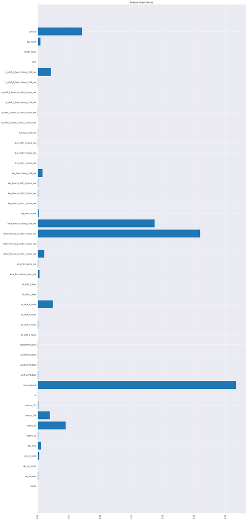

```python
%%time
dataset = datasets[5].copy()
regressor = xgb.XGBRegressor(random_state=42,max_depth=7,colsample_bytree= 0.5, learning_rate = 0.2,
                             min_child_weight= 3,n_estimators=700,objective='reg:squarederror')
cols = ['srmx_forecast','day_hour','ts','ts_shift_1_hours','ts_shift_2_hours','ts_shift_4_hours','history_168']
error1 = error_estimation(dataset, params_prep = [2,0,4,2,2,23],
                 fill_empty = False,ts_mean_values=None,
                 cat_encoder = TargetEncoder(),
                 cols_to_drop=[],
                 cols_to_mix_feats = cols ,
                 cols_for_q=[],cols_for_c = [],
                 train_lims = ['2016-02-01 00:00:00','2016-05-01 00:00:00'],
                 reg_algo = regressor,
                 verbose=True,
                 show_fe_importances=True
                 )
gc.collect()
```

Посмотрим на работу модели на остальных датасетах, только на минимальном числе деревьев, чтобы убедиться в схожем поведении и качестве.

```
------------------
Solving with params[2, 0, 4, 2, 2, 23]
------------------
------------------
creation harmonic_fe, autoreg_fe completed
------------------
------------------
creation deriv_feats completed
------------------
------------------
prep datasets completed
------------------
------------------
preproc completed
------------------
------------------
fitting the model...
------------------
model fitted
------------------
------------------
predicting and scoring...
------------------
params[k1,k2,k3,k4,k5,k6]: [2, 0, 4, 2, 2, 23],mean absolute error: 29.210706100254644
------------------
------------------
CPU times: user 40.3 s, sys: 989 ms, total: 41.3 s
Wall time: 41.2 s
```

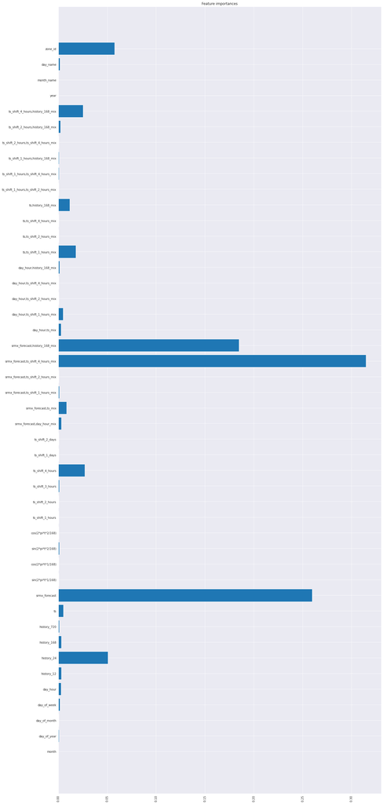

```python
%%time
dataset = datasets[1].copy()
regressor = xgb.XGBRegressor(random_state=42,max_depth=7,colsample_bytree= 0.5, learning_rate = 0.2,
                             min_child_weight= 3,n_estimators=50,objective='reg:squarederror')
cols = ['srmx_forecast','day_hour','ts','ts_shift_1_hours','ts_shift_2_hours','ts_shift_4_hours','history_168']
error1 = error_estimation(dataset, params_prep = [2,0,4,2,2,23],
                 fill_empty = False,ts_mean_values=None,
                 cat_encoder = TargetEncoder(),
                 cols_to_drop=[],
                 cols_to_mix_feats = cols ,
                 cols_for_q=[],cols_for_c = [],
                 train_lims = ['2016-02-01 00:00:00','2016-05-01 00:00:00'],
                 reg_algo = regressor,
                 verbose=True,
                 show_fe_importances=True
                 )
gc.collect()
```

```
------------------
Solving with params[2, 0, 4, 2, 2, 23]
------------------
------------------
creation harmonic_fe, autoreg_fe completed
------------------
------------------
creation deriv_feats completed
------------------
------------------
prep datasets completed
------------------
------------------
preproc completed
------------------
------------------
fitting the model...
------------------
model fitted
------------------
------------------
predicting and scoring...
------------------
params[k1,k2,k3,k4,k5,k6]: [2, 0, 4, 2, 2, 23],mean absolute error: 29.93875962873988
------------------
------------------
CPU times: user 41.5 s, sys: 351 ms, total: 41.8 s
Wall time: 41.8 s
```

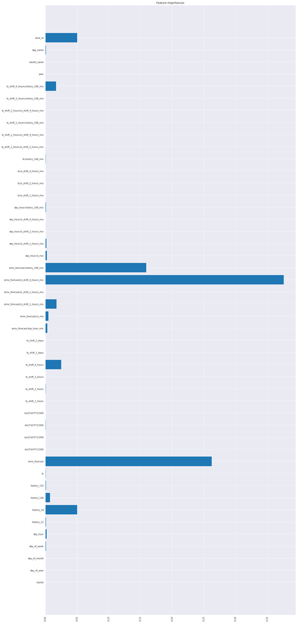

```python
%%time
dataset = datasets[2].copy()
regressor = xgb.XGBRegressor(random_state=42,max_depth=7,colsample_bytree= 0.5, learning_rate = 0.2,
                             min_child_weight= 3,n_estimators=50,objective='reg:squarederror')
cols = ['srmx_forecast','day_hour','ts','ts_shift_1_hours','ts_shift_2_hours','ts_shift_4_hours','history_168']
error1 = error_estimation(dataset, params_prep = [2,0,4,2,2,23],
                 fill_empty = False,ts_mean_values=None,
                 cat_encoder = TargetEncoder(),
                 cols_to_drop=[],
                 cols_to_mix_feats = cols ,
                 cols_for_q=[],cols_for_c = [],
                 train_lims = ['2016-02-01 00:00:00','2016-05-01 00:00:00'],
                 reg_algo = regressor,
                 verbose=True,
                 show_fe_importances=True
                 )
gc.collect()
```

```
------------------
Solving with params[2, 0, 4, 2, 2, 23]
------------------
------------------
creation harmonic_fe, autoreg_fe completed
------------------
------------------
creation deriv_feats completed
------------------
------------------
prep datasets completed
------------------
------------------
preproc completed
------------------
------------------
fitting the model...
------------------
model fitted
------------------
------------------
predicting and scoring...
------------------
params[k1,k2,k3,k4,k5,k6]: [2, 0, 4, 2, 2, 23],mean absolute error: 29.970866500155935
------------------
------------------
CPU times: user 40.1 s, sys: 237 ms, total: 40.3 s
Wall time: 40.2 s
```

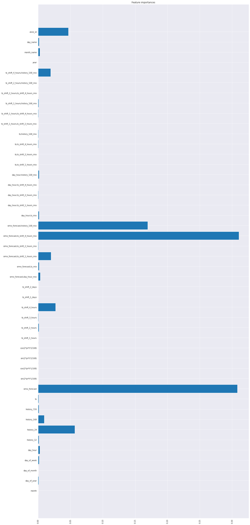

```python
%%time
dataset = datasets[3].copy()
regressor = xgb.XGBRegressor(random_state=42,max_depth=7,colsample_bytree= 0.5, learning_rate = 0.2,
                             min_child_weight= 3,n_estimators=50,objective='reg:squarederror')
cols = ['srmx_forecast','day_hour','ts','ts_shift_1_hours','ts_shift_2_hours','ts_shift_4_hours','history_168']
error1 = error_estimation(dataset, params_prep = [2,0,4,2,2,23],
                 fill_empty = False,ts_mean_values=None,
                 cat_encoder = TargetEncoder(),
                 cols_to_drop=[],
                 cols_to_mix_feats = cols ,
                 cols_for_q=[],cols_for_c = [],
                 train_lims = ['2016-02-01 00:00:00','2016-05-01 00:00:00'],
                 reg_algo = regressor,
                 verbose=True,
                 show_fe_importances=True
                 )
gc.collect()
```

```
------------------
Solving with params[2, 0, 4, 2, 2, 23]
------------------
------------------
creation harmonic_fe, autoreg_fe completed
------------------
------------------
creation deriv_feats completed
------------------
------------------
prep datasets completed
------------------
------------------
preproc completed
------------------
------------------
fitting the model...
------------------
model fitted
------------------
------------------
predicting and scoring...
------------------
params[k1,k2,k3,k4,k5,k6]: [2, 0, 4, 2, 2, 23],mean absolute error: 29.496191973480073
------------------
------------------
CPU times: user 40.1 s, sys: 233 ms, total: 40.4 s
Wall time: 40.3 s
```

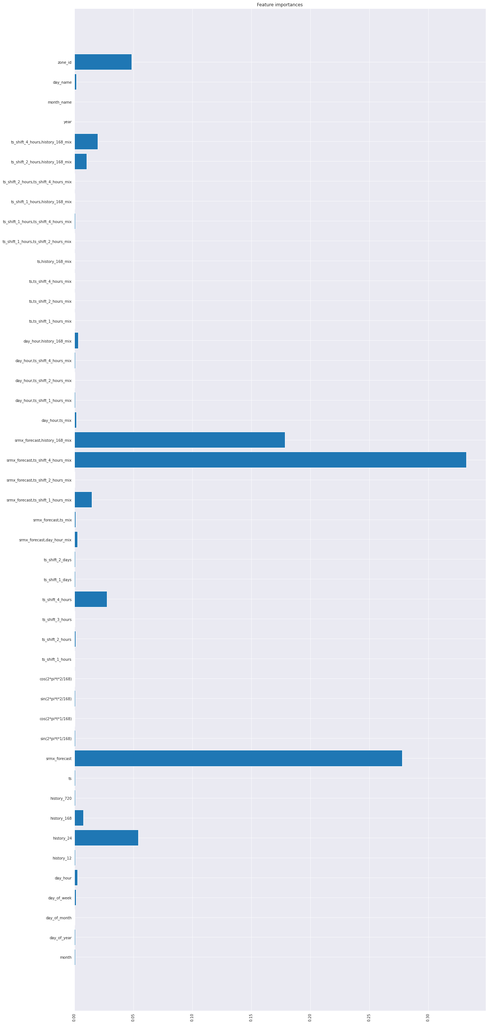

```python
%%time
dataset = datasets[4].copy()
regressor = xgb.XGBRegressor(random_state=42,max_depth=7,colsample_bytree= 0.5, learning_rate = 0.2,
                             min_child_weight= 3,n_estimators=50,objective='reg:squarederror')
cols = ['srmx_forecast','day_hour','ts','ts_shift_1_hours','ts_shift_2_hours','ts_shift_4_hours','history_168']
error1 = error_estimation(dataset, params_prep = [2,0,4,2,2,23],
                 fill_empty = False,ts_mean_values=None,
                 cat_encoder = TargetEncoder(),
                 cols_to_drop=[],
                 cols_to_mix_feats = cols ,
                 cols_for_q=[],cols_for_c = [],
                 train_lims = ['2016-02-01 00:00:00','2016-05-01 00:00:00'],
                 reg_algo = regressor,
                 verbose=True,
                 show_fe_importances=True
                 )
gc.collect()
```

Создадим функции для задания итоговых моделей и подготовки тестовых данных

```python
def create_model(data,params_prep,cols_to_mix_feats=[],cols_for_q=[],cols_for_c=[],
                     cat_encoder =TargetEncoder(),
                     train_lims = ['2015-12-01 00:00:00','2016-05-01 00:00:00'],
                     cols_to_drop=[],reg_algo=None,fill_empty=False,ts_mean_values=None,verbose=False,
                     show_fe_importances = False):
  dataset = data.copy()

  [k1,k2,k3,k4,k5,k6] = params_prep
  warnings.filterwarnings('ignore')
  if verbose:
    print('------------------')
    print(f'Solving with params{[k1,k2,k3,k4,k5,k6]}')
    print('------------------')
  harmonic_fe = harmonic_feats(dataset,kw=k1,ky=k2,linear_fe=False)

  autoreg_fe = autoreg_feats(dataset,k = k3 ,kd = k4,fill_empty=fill_empty,ts_mean_values=ts_mean_values)

  if verbose:
    print('------------------')
    print('creation harmonic_fe, autoreg_fe completed')
    print('------------------')

  dataset_mid = pd.concat([dataset,harmonic_fe,autoreg_fe],axis=1)



  mixed_feats = normed_fe_interaction(dataset_mid[cols_to_mix_feats],level=k5,max_feats = k6)
  squares = squared_feats(dataset_mid[cols_for_q])
  cubes = cubic_feats(dataset_mid[cols_for_c])
  deriv_feats = pd.concat([squares,cubes,mixed_feats],axis = 1)
  if verbose:
    print('------------------')
    print('creation deriv_feats completed')
    print('------------------')

  dataset_res = pd.concat([dataset_mid,deriv_feats],axis=1).drop(columns=cols_to_drop)

  dataset_train = dataset_res[dataset_res.datetime < pd.to_datetime(train_lims[1])][dataset_res.datetime \
                                                                                    >= pd.to_datetime(train_lims[0])].copy()
  if verbose:
    print('------------------')
    print('prep dataset completed')
    print('------------------')

  cat_cols = ['year','month_name','day_name', 'zone_id']
  cols_not_num = ['hour_counter','year','month_name','day_name','datetime','zone_id','target']
  num_indices = np.array([col not in cols_not_num for col in dataset_res.drop(columns=['target']).columns],dtype=bool)
  cat_indices = np.array([col in cat_cols for col in dataset_res.drop(columns=['target']).columns],dtype=bool)

  cat_transformer = cat_encoder

  gc.collect()

  if verbose:
    print('------------------')
    print('preproc completed')
    print('------------------')

  transformer =  fe_transformer(num_indices,cat_indices,cat_transformer)
  regressor =  reg_algo

  if verbose:
    print('------------------')
    print('fitting the model...')

  model = Estimator(transformer,regressor)
  model.fit(dataset_train.drop(columns=['target']).values,dataset_train.target.values)


  if verbose:
    print('------------------')
    print('model fitted')
    print('------------------')
    print(model)

  if show_fe_importances:
    plt.figure(figsize=(20,50))

    feature_importances = model.regressor.feature_importances_


    num_names = np.array(dataset_train.drop(columns=['target']).columns)[num_indices]
    cat_names = np.array(dataset_train.drop(columns=['target']).columns)[cat_indices]
    fe_names = np.hstack([num_names,cat_names])
    plt.barh(fe_names, feature_importances)
    plt.title('Feature importances')
    plt.xticks(rotation=90)

  return model
```

Протестируем функцию

```
------------------
Solving with params[2, 0, 4, 2, 2, 23]
------------------
------------------
creation harmonic_fe, autoreg_fe completed
------------------
------------------
creation deriv_feats completed
------------------
------------------
prep dataset completed
------------------
------------------
preproc completed
------------------
------------------
fitting the model...
------------------
model fitted
------------------
Estimator(regressor=XGBRegressor(base_score=0.5, booster='gbtree',
                                 colsample_bylevel=1, colsample_bynode=1,
                                 colsample_bytree=0.5, gamma=0,
                                 importance_type='gain', learning_rate=0.2,
                                 max_delta_step=0, max_depth=7,
                                 min_child_weight=3, missing=None,
                                 n_estimators=50, n_jobs=1, nthread=None,
                                 objective='reg:squarederror', random_state=42,
                                 reg_alpha=0, reg_lambda=1, scale_p...
                                                                                           func=<function fe_transformer.<locals>.<lambda> at 0x7efc0ca157b8>,
                                                                                           inv_kw_args=None,
                                                                                           inverse_func=None,
                                                                                           kw_args=None,
                                                                                           validate=False)),
                                                                      ('cat_transformer',
                                                                       TargetEncoder(cols=[0,
                                                                                           1,
                                                                                           2,
                                                                                           3],
                                                                                     drop_invariant=False,
                                                                                     handle_missing='value',
                                                                                     handle_unknown='value',
                                                                                     min_samples_leaf=1,
                                                                                     return_df=True,
                                                                                     smoothing=1.0,
                                                                                     verbose=0))],
                                                               verbose=False))],
                                   transformer_weights=None, verbose=False))
CPU times: user 39 s, sys: 425 ms, total: 39.4 s
Wall time: 39.4 s
```

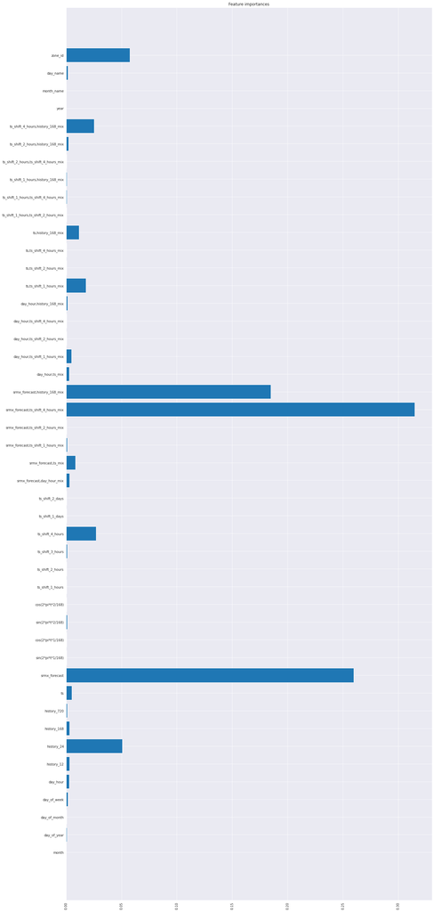

```python
%%time
dataset = datasets[1].copy()
regressor = xgb.XGBRegressor(random_state=42,max_depth=7,colsample_bytree= 0.5, learning_rate = 0.2,
                             min_child_weight= 3,n_estimators=50,objective='reg:squarederror')
cols = ['srmx_forecast','day_hour','ts','ts_shift_1_hours','ts_shift_2_hours','ts_shift_4_hours','history_168']
model_00 = create_model(dataset, params_prep = [2,0,4,2,2,23],
                 fill_empty = False,ts_mean_values=None,
                 cat_encoder = TargetEncoder(),
                 cols_to_drop=[],
                 cols_to_mix_feats = cols ,
                 cols_for_q=[],cols_for_c = [],
                 train_lims = ['2016-02-01 00:00:00','2016-05-01 00:00:00'],
                 reg_algo = regressor,
                 verbose=True,
                 show_fe_importances=True
                 )
gc.collect()
```

```python
def prepare_data_to_predict(data,params_prep,cols_to_mix_feats=[],cols_for_q=[],cols_for_c=[],
                     test_lims = ['2016-05-01 00:00:00','2016-06-01 00:00:00'],
                     cols_to_drop=[],fill_empty=False,ts_mean_values=None,verbose=False):
  dataset = data.copy()

  [k1,k2,k3,k4,k5,k6] = params_prep
  warnings.filterwarnings('ignore')
  if verbose:
    print('------------------')
    print(f'Solving with params{[k1,k2,k3,k4,k5,k6]}')
    print('------------------')
  harmonic_fe = harmonic_feats(dataset,kw=k1,ky=k2,linear_fe=False)

  autoreg_fe = autoreg_feats(dataset,k = k3 ,kd = k4,fill_empty=fill_empty,ts_mean_values=ts_mean_values)

  if verbose:
    print('------------------')
    print('creation harmonic_fe, autoreg_fe completed')
    print('------------------')

  dataset_mid = pd.concat([dataset,harmonic_fe,autoreg_fe],axis=1)



  mixed_feats = normed_fe_interaction(dataset_mid[cols_to_mix_feats],level=k5,max_feats = k6)
  squares = squared_feats(dataset_mid[cols_for_q])
  cubes = cubic_feats(dataset_mid[cols_for_c])
  deriv_feats = pd.concat([squares,cubes,mixed_feats],axis = 1)
  if verbose:
    print('------------------')
    print('creation deriv_feats completed')
    print('------------------')

  dataset_res = pd.concat([dataset_mid,deriv_feats],axis=1).drop(columns=cols_to_drop)

  dataset_test = dataset_res[dataset_res.datetime < pd.to_datetime(test_lims[1])][dataset_res.datetime \
                                                                                    >= pd.to_datetime(test_lims[0])].copy()
  if verbose:
    print('------------------')
    print('prep dataset completed')
    print('------------------')


  return  dataset_test
```

Протестируем функцию

```python
%%time
dataset = datasets[1].copy()
cols = ['srmx_forecast','day_hour','ts','ts_shift_1_hours','ts_shift_2_hours','ts_shift_4_hours','history_168']
data_may = prepare_data_to_predict(dataset, params_prep = [2,0,4,2,2,23],
                 fill_empty = False,ts_mean_values=None,
                 cols_to_drop=[],
                 cols_to_mix_feats = cols ,
                 cols_for_q=[],cols_for_c = [],
                 test_lims = ['2016-05-01 00:00:00','2016-06-01 00:00:00'],
                 verbose=True,
                 )
data_may.head()
```

```
------------------
Solving with params[2, 0, 4, 2, 2, 23]
------------------
------------------
creation harmonic_fe, autoreg_fe completed
------------------
------------------
creation deriv_feats completed
------------------
------------------
prep dataset completed
------------------
CPU times: user 3.8 s, sys: 34.1 ms, total: 3.84 s
Wall time: 3.78 s
```

```python
data_may.head()
```

|  | hour_counter | year | month | month_name | day_of_year | day_of_month | day_of_week | day_name | day_hour | zone_id | datetime | history_12 | history_24 | history_168 | history_720 | ts | srmx_forecast | target | sin(2*pi*t*1/168) | cos(2*pi*t*1/168) | sin(2*pi*t*2/168) | cos(2*pi*t*2/168) | ts_shift_1_hours | ts_shift_2_hours | ts_shift_3_hours | ts_shift_4_hours | ts_shift_1_days | ts_shift_2_days | srmx_forecast,day_hour_mix | … |
| --- | --- | --- | --- | --- | --- | --- | --- | --- | --- | --- | --- | --- | --- | --- | --- | --- | --- | --- | --- | --- | --- | --- | --- | --- | --- | --- | --- | --- | --- | --- |
| 3648 | 3649.0 | 2016.0 | 5.0 | May | 122.0 | 1.0 | 6.0 | Sunday | 0.0 | 1075.0 | 2016-05-01 00:00:00 | 1589.0 | 2016.0 | 11284.0 | 48162.0 | 71.0 | 23.911220 | 10.0 | -0.982566 | -0.185912 | 0.365341 | -0.930874 | 92.0 | 100.0 | 91.0 | 107.0 | 67.0 | 40.0 | 0.848262 | … |
| 3649 | 3650.0 | 2016.0 | 5.0 | May | 122.0 | 1.0 | 6.0 | Sunday | 1.0 | 1075.0 | 2016-05-01 01:00:00 | 1506.0 | 1986.0 | 11270.0 | 48153.0 | 37.0 | 9.134244 | 14.0 | -0.988831 | -0.149042 | 0.294755 | -0.955573 | 71.0 | 92.0 | 100.0 | 91.0 | 48.0 | 19.0 | 0.865729 | … |
| 3650 | 3651.0 | 2016.0 | 5.0 | May | 122.0 | 1.0 | 6.0 | Sunday | 2.0 | 1075.0 | 2016-05-01 02:00:00 | 1373.0 | 1948.0 | 11244.0 | 48138.0 | 10.0 | 5.326245 | 6.0 | -0.993712 | -0.111964 | 0.222521 | -0.974928 | 37.0 | 71.0 | 92.0 | 100.0 | 27.0 | 16.0 | 0.804479 | … |
| 3651 | 3652.0 | 2016.0 | 5.0 | May | 122.0 | 1.0 | 6.0 | Sunday | 3.0 | 1075.0 | 2016-05-01 03:00:00 | 1249.0 | 1935.0 | 11235.0 | 48140.0 | 14.0 | -0.799037 | 8.0 | -0.997204 | -0.074730 | 0.149042 | -0.988831 | 10.0 | 37.0 | 71.0 | 92.0 | 13.0 | 6.0 | 0.750331 | … |
| 3652 | 3653.0 | 2016.0 | 5.0 | May | 122.0 | 1.0 | 6.0 | Sunday | 4.0 | 1075.0 | 2016-05-01 04:00:00 | 1110.0 | 1928.0 | 11224.0 | 48138.0 | 6.0 | 7.916882 | 10.0 | -0.999301 | -0.037391 | 0.074730 | -0.997204 | 14.0 | 10.0 | 37.0 | 71.0 | 20.0 | 2.0 | 0.623498 | … |

```python
  prediction_may0  = model_00.predict(data_may.drop(columns=['target']).values)
  error0 = mae(data_may.target,prediction_may0)
  error0
```

```
29.210706100254644
```

Итак, преступаем к обучению. Сначала будут обучены 6 моделей и получена ошибка на данных за май, а затем еще 6 моделей и получены предсказания на июнь.

```python
%%time
dataset = datasets[0].copy()
regressor = xgb.XGBRegressor(random_state=42,max_depth=7, learning_rate=0.2,n_estimators=1000,objective='reg:squarederror')
cols = ['day_hour','history_168','history_24','ts','history_720']
model_1_may = create_model(dataset, params_prep = [0,0,2,2,4,23],
                 fill_empty = False,ts_mean_values=None,
                 cat_encoder = TargetEncoder(),
                 cols_to_drop=['srmx_forecast'],
                 cols_to_mix_feats = cols ,
                 cols_for_q=[],cols_for_c = [],
                 train_lims = ['2016-02-01 00:00:00','2016-04-30 23:00:00'],
                 reg_algo = regressor,
                 verbose=True,
                 show_fe_importances=False
                 )
gc.collect()


data_may1 = prepare_data_to_predict(dataset, params_prep = [0,0,2,2,4,23],
                 fill_empty = False,ts_mean_values=None,
                 cols_to_drop=['srmx_forecast'],
                 cols_to_mix_feats = cols ,
                 cols_for_q=[],cols_for_c = [],
                 test_lims = ['2016-04-30 23:00:00','2016-05-31 18:00:00'],
                 verbose=True,
                 )

gc.collect()
```

```
------------------
Solving with params[0, 0, 2, 2, 4, 23]
------------------
------------------
creation harmonic_fe, autoreg_fe completed
------------------
------------------
creation deriv_feats completed
------------------
------------------
prep dataset completed
------------------
------------------
preproc completed
------------------
------------------
fitting the model...
------------------
model fitted
------------------
Estimator(regressor=XGBRegressor(base_score=0.5, booster='gbtree',
                                 colsample_bylevel=1, colsample_bynode=1,
                                 colsample_bytree=1, gamma=0,
                                 importance_type='gain', learning_rate=0.2,
                                 max_delta_step=0, max_depth=7,
                                 min_child_weight=1, missing=None,
                                 n_estimators=1000, n_jobs=1, nthread=None,
                                 objective='reg:squarederror', random_state=42,
                                 reg_alpha=0, reg_lambda=1, scale_p...
                                                                                           func=<function fe_transformer.<locals>.<lambda> at 0x7f3f477dcae8>,
                                                                                           inv_kw_args=None,
                                                                                           inverse_func=None,
                                                                                           kw_args=None,
                                                                                           validate=False)),
                                                                      ('cat_transformer',
                                                                       TargetEncoder(cols=[0,
                                                                                           1,
                                                                                           2,
                                                                                           3],
                                                                                     drop_invariant=False,
                                                                                     handle_missing='value',
                                                                                     handle_unknown='value',
                                                                                     min_samples_leaf=1,
                                                                                     return_df=True,
                                                                                     smoothing=1.0,
                                                                                     verbose=0))],
                                                               verbose=False))],
                                   transformer_weights=None, verbose=False))
------------------
Solving with params[0, 0, 2, 2, 4, 23]
------------------
------------------
creation harmonic_fe, autoreg_fe completed
------------------
------------------
creation deriv_feats completed
------------------
------------------
prep dataset completed
------------------
CPU times: user 9min 22s, sys: 931 ms, total: 9min 23s
Wall time: 9min 23s
```

```python
%%time
dataset = datasets[1].copy()
regressor = xgb.XGBRegressor(random_state=42,max_depth=7,colsample_bytree= 0.5, learning_rate = 0.2,
                             min_child_weight= 3,n_estimators=700,objective='reg:squarederror')
cols = ['srmx_forecast','day_hour','ts','ts_shift_1_hours','ts_shift_2_hours','ts_shift_4_hours','history_168']
model_2_may = create_model(dataset, params_prep = [2,0,4,2,2,23],
                 fill_empty = False,ts_mean_values=None,
                 cat_encoder = TargetEncoder(),
                 cols_to_drop=[],
                 cols_to_mix_feats = cols ,
                 cols_for_q=[],cols_for_c = [],
                 train_lims = ['2016-02-01 00:00:00','2016-04-30 23:00:00'],
                 reg_algo = regressor,
                 verbose=True,
                 show_fe_importances=False
                 )
gc.collect()


data_may2 = prepare_data_to_predict(dataset, params_prep = [2,0,4,2,2,23],
                 fill_empty = False,ts_mean_values=None,
                 cols_to_drop=[],
                 cols_to_mix_feats = cols ,
                 cols_for_q=[],cols_for_c = [],
                 test_lims = ['2016-04-30 23:00:00','2016-05-31 18:00:00'],
                 verbose=True,
                 )

gc.collect()
```

```
------------------
Solving with params[2, 0, 4, 2, 2, 23]
------------------
------------------
creation harmonic_fe, autoreg_fe completed
------------------
------------------
creation deriv_feats completed
------------------
------------------
prep dataset completed
------------------
------------------
preproc completed
------------------
------------------
fitting the model...
------------------
model fitted
------------------
Estimator(regressor=XGBRegressor(base_score=0.5, booster='gbtree',
                                 colsample_bylevel=1, colsample_bynode=1,
                                 colsample_bytree=0.5, gamma=0,
                                 importance_type='gain', learning_rate=0.2,
                                 max_delta_step=0, max_depth=7,
                                 min_child_weight=3, missing=None,
                                 n_estimators=700, n_jobs=1, nthread=None,
                                 objective='reg:squarederror', random_state=42,
                                 reg_alpha=0, reg_lambda=1, scale_...
                                                                                           func=<function fe_transformer.<locals>.<lambda> at 0x7f3f3db1a1e0>,
                                                                                           inv_kw_args=None,
                                                                                           inverse_func=None,
                                                                                           kw_args=None,
                                                                                           validate=False)),
                                                                      ('cat_transformer',
                                                                       TargetEncoder(cols=[0,
                                                                                           1,
                                                                                           2,
                                                                                           3],
                                                                                     drop_invariant=False,
                                                                                     handle_missing='value',
                                                                                     handle_unknown='value',
                                                                                     min_samples_leaf=1,
                                                                                     return_df=True,
                                                                                     smoothing=1.0,
                                                                                     verbose=0))],
                                                               verbose=False))],
                                   transformer_weights=None, verbose=False))
------------------
Solving with params[2, 0, 4, 2, 2, 23]
------------------
------------------
creation harmonic_fe, autoreg_fe completed
------------------
------------------
creation deriv_feats completed
------------------
------------------
prep dataset completed
------------------
CPU times: user 7min 32s, sys: 986 ms, total: 7min 33s
Wall time: 7min 33s
```

```python
%%time
dataset = datasets[2].copy()
regressor = xgb.XGBRegressor(random_state=42,max_depth=7,colsample_bytree= 0.5, learning_rate = 0.2,
                             min_child_weight= 3,n_estimators=700,objective='reg:squarederror')
cols = ['srmx_forecast','day_hour','ts','ts_shift_1_hours','ts_shift_2_hours','ts_shift_4_hours','history_168']
model_3_may = create_model(dataset, params_prep = [2,0,4,2,2,23],
                 fill_empty = False,ts_mean_values=None,
                 cat_encoder = TargetEncoder(),
                 cols_to_drop=[],
                 cols_to_mix_feats = cols ,
                 cols_for_q=[],cols_for_c = [],
                 train_lims = ['2016-02-01 00:00:00','2016-04-30 23:00:00'],
                 reg_algo = regressor,
                 verbose=True,
                 show_fe_importances=False
                 )
gc.collect()


data_may3 = prepare_data_to_predict(dataset, params_prep = [2,0,4,2,2,23],
                 fill_empty = False,ts_mean_values=None,
                 cols_to_drop=[],
                 cols_to_mix_feats = cols ,
                 cols_for_q=[],cols_for_c = [],
                 test_lims = ['2016-04-30 23:00:00','2016-05-31 18:00:00'],
                 verbose=True,
                 )

gc.collect()
```

```
------------------
Solving with params[2, 0, 4, 2, 2, 23]
------------------
------------------
creation harmonic_fe, autoreg_fe completed
------------------
------------------
creation deriv_feats completed
------------------
------------------
prep dataset completed
------------------
------------------
preproc completed
------------------
------------------
fitting the model...
------------------
model fitted
------------------
Estimator(regressor=XGBRegressor(base_score=0.5, booster='gbtree',
                                 colsample_bylevel=1, colsample_bynode=1,
                                 colsample_bytree=0.5, gamma=0,
                                 importance_type='gain', learning_rate=0.2,
                                 max_delta_step=0, max_depth=7,
                                 min_child_weight=3, missing=None,
                                 n_estimators=700, n_jobs=1, nthread=None,
                                 objective='reg:squarederror', random_state=42,
                                 reg_alpha=0, reg_lambda=1, scale_...
                                                                                           func=<function fe_transformer.<locals>.<lambda> at 0x7f3f475be6a8>,
                                                                                           inv_kw_args=None,
                                                                                           inverse_func=None,
                                                                                           kw_args=None,
                                                                                           validate=False)),
                                                                      ('cat_transformer',
                                                                       TargetEncoder(cols=[0,
                                                                                           1,
                                                                                           2,
                                                                                           3],
                                                                                     drop_invariant=False,
                                                                                     handle_missing='value',
                                                                                     handle_unknown='value',
                                                                                     min_samples_leaf=1,
                                                                                     return_df=True,
                                                                                     smoothing=1.0,
                                                                                     verbose=0))],
                                                               verbose=False))],
                                   transformer_weights=None, verbose=False))
------------------
Solving with params[2, 0, 4, 2, 2, 23]
------------------
------------------
creation harmonic_fe, autoreg_fe completed
------------------
------------------
creation deriv_feats completed
------------------
------------------
prep dataset completed
------------------
CPU times: user 7min 34s, sys: 527 ms, total: 7min 34s
Wall time: 7min 34s
```

```python
%%time
dataset = datasets[3].copy()
regressor = xgb.XGBRegressor(random_state=42,max_depth=7,colsample_bytree= 0.5, learning_rate = 0.2,
                             min_child_weight= 3,n_estimators=700,objective='reg:squarederror')
cols = ['srmx_forecast','day_hour','ts','ts_shift_1_hours','ts_shift_2_hours','ts_shift_4_hours','history_168']
model_4_may = create_model(dataset, params_prep = [2,0,4,2,2,23],
                 fill_empty = False,ts_mean_values=None,
                 cat_encoder = TargetEncoder(),
                 cols_to_drop=[],
                 cols_to_mix_feats = cols ,
                 cols_for_q=[],cols_for_c = [],
                 train_lims = ['2016-02-01 00:00:00','2016-04-30 23:00:00'],
                 reg_algo = regressor,
                 verbose=True,
                 show_fe_importances=False
                 )
gc.collect()


data_may4 = prepare_data_to_predict(dataset, params_prep = [2,0,4,2,2,23],
                 fill_empty = False,ts_mean_values=None,
                 cols_to_drop=[],
                 cols_to_mix_feats = cols ,
                 cols_for_q=[],cols_for_c = [],
                 test_lims = ['2016-04-30 23:00:00','2016-05-31 18:00:00'],
                 verbose=True,
                 )

gc.collect()
```

```
------------------
Solving with params[2, 0, 4, 2, 2, 23]
------------------
------------------
creation harmonic_fe, autoreg_fe completed
------------------
------------------
creation deriv_feats completed
------------------
------------------
prep dataset completed
------------------
------------------
preproc completed
------------------
------------------
fitting the model...
------------------
model fitted
------------------
Estimator(regressor=XGBRegressor(base_score=0.5, booster='gbtree',
                                 colsample_bylevel=1, colsample_bynode=1,
                                 colsample_bytree=0.5, gamma=0,
                                 importance_type='gain', learning_rate=0.2,
                                 max_delta_step=0, max_depth=7,
                                 min_child_weight=3, missing=None,
                                 n_estimators=700, n_jobs=1, nthread=None,
                                 objective='reg:squarederror', random_state=42,
                                 reg_alpha=0, reg_lambda=1, scale_...
                                                                                           func=<function fe_transformer.<locals>.<lambda> at 0x7f3f365681e0>,
                                                                                           inv_kw_args=None,
                                                                                           inverse_func=None,
                                                                                           kw_args=None,
                                                                                           validate=False)),
                                                                      ('cat_transformer',
                                                                       TargetEncoder(cols=[0,
                                                                                           1,
                                                                                           2,
                                                                                           3],
                                                                                     drop_invariant=False,
                                                                                     handle_missing='value',
                                                                                     handle_unknown='value',
                                                                                     min_samples_leaf=1,
                                                                                     return_df=True,
                                                                                     smoothing=1.0,
                                                                                     verbose=0))],
                                                               verbose=False))],
                                   transformer_weights=None, verbose=False))
------------------
Solving with params[2, 0, 4, 2, 2, 23]
------------------
------------------
creation harmonic_fe, autoreg_fe completed
------------------
------------------
creation deriv_feats completed
------------------
------------------
prep dataset completed
------------------
CPU times: user 7min 34s, sys: 452 ms, total: 7min 34s
Wall time: 7min 34s
```

```python
%%time
dataset = datasets[4].copy()
regressor = xgb.XGBRegressor(random_state=42,max_depth=7,colsample_bytree= 0.5, learning_rate = 0.2,
                             min_child_weight= 3,n_estimators=700,objective='reg:squarederror')
cols = ['srmx_forecast','day_hour','ts','ts_shift_1_hours','ts_shift_2_hours','ts_shift_4_hours','history_168']
model_5_may = create_model(dataset, params_prep = [2,0,4,2,2,23],
                 fill_empty = False,ts_mean_values=None,
                 cat_encoder = TargetEncoder(),
                 cols_to_drop=[],
                 cols_to_mix_feats = cols ,
                 cols_for_q=[],cols_for_c = [],
                 train_lims = ['2016-02-01 00:00:00','2016-04-30 23:00:00'],
                 reg_algo = regressor,
                 verbose=True,
                 show_fe_importances=False
                 )
gc.collect()

data_may5 = prepare_data_to_predict(dataset, params_prep = [2,0,4,2,2,23],
                 fill_empty = False,ts_mean_values=None,
                 cols_to_drop=[],
                 cols_to_mix_feats = cols ,
                 cols_for_q=[],cols_for_c = [],
                 test_lims = ['2016-04-30 23:00:00','2016-05-31 18:00:00'],
                 verbose=True,
                 )

gc.collect()
```

```
------------------
Solving with params[2, 0, 4, 2, 2, 23]
------------------
------------------
creation harmonic_fe, autoreg_fe completed
------------------
------------------
creation deriv_feats completed
------------------
------------------
prep dataset completed
------------------
------------------
preproc completed
------------------
------------------
fitting the model...
------------------
model fitted
------------------
Estimator(regressor=XGBRegressor(base_score=0.5, booster='gbtree',
                                 colsample_bylevel=1, colsample_bynode=1,
                                 colsample_bytree=0.5, gamma=0,
                                 importance_type='gain', learning_rate=0.2,
                                 max_delta_step=0, max_depth=7,
                                 min_child_weight=3, missing=None,
                                 n_estimators=700, n_jobs=1, nthread=None,
                                 objective='reg:squarederror', random_state=42,
                                 reg_alpha=0, reg_lambda=1, scale_...
                                                                                           func=<function fe_transformer.<locals>.<lambda> at 0x7f3f364b8378>,
                                                                                           inv_kw_args=None,
                                                                                           inverse_func=None,
                                                                                           kw_args=None,
                                                                                           validate=False)),
                                                                      ('cat_transformer',
                                                                       TargetEncoder(cols=[0,
                                                                                           1,
                                                                                           2,
                                                                                           3],
                                                                                     drop_invariant=False,
                                                                                     handle_missing='value',
                                                                                     handle_unknown='value',
                                                                                     min_samples_leaf=1,
                                                                                     return_df=True,
                                                                                     smoothing=1.0,
                                                                                     verbose=0))],
                                                               verbose=False))],
                                   transformer_weights=None, verbose=False))
------------------
Solving with params[2, 0, 4, 2, 2, 23]
------------------
------------------
creation harmonic_fe, autoreg_fe completed
------------------
------------------
creation deriv_feats completed
------------------
------------------
prep dataset completed
------------------
CPU times: user 7min 38s, sys: 719 ms, total: 7min 39s
Wall time: 7min 40s
```

```python
%%time
dataset = datasets[5].copy()
regressor = xgb.XGBRegressor(random_state=42,max_depth=7,colsample_bytree= 0.5, learning_rate = 0.2,
                             min_child_weight= 3,n_estimators=700,objective='reg:squarederror')
cols = ['srmx_forecast','day_hour','ts','ts_shift_1_hours','ts_shift_2_hours','ts_shift_4_hours','history_168']
model_6_may = create_model(dataset, params_prep = [2,0,4,2,2,23],
                 fill_empty = False,ts_mean_values=None,
                 cat_encoder = TargetEncoder(),
                 cols_to_drop=[],
                 cols_to_mix_feats = cols ,
                 cols_for_q=[],cols_for_c = [],
                 train_lims = ['2016-02-01 00:00:00','2016-04-30 23:00:00'],
                 reg_algo = regressor,
                 verbose=True,
                 show_fe_importances=False
                 )
gc.collect()

data_may6 = prepare_data_to_predict(dataset, params_prep = [2,0,4,2,2,23],
                 fill_empty = False,ts_mean_values=None,
                 cols_to_drop=[],
                 cols_to_mix_feats = cols ,
                 cols_for_q=[],cols_for_c = [],
                 test_lims = ['2016-04-30 23:00:00','2016-05-31 18:00:00'],
                 verbose=True,
                 )

gc.collect()
```

```
------------------
Solving with params[2, 0, 4, 2, 2, 23]
------------------
------------------
creation harmonic_fe, autoreg_fe completed
------------------
------------------
creation deriv_feats completed
------------------
------------------
prep dataset completed
------------------
------------------
preproc completed
------------------
------------------
fitting the model...
------------------
model fitted
------------------
Estimator(regressor=XGBRegressor(base_score=0.5, booster='gbtree',
                                 colsample_bylevel=1, colsample_bynode=1,
                                 colsample_bytree=0.5, gamma=0,
                                 importance_type='gain', learning_rate=0.2,
                                 max_delta_step=0, max_depth=7,
                                 min_child_weight=3, missing=None,
                                 n_estimators=700, n_jobs=1, nthread=None,
                                 objective='reg:squarederror', random_state=42,
                                 reg_alpha=0, reg_lambda=1, scale_...
                                                                                           func=<function fe_transformer.<locals>.<lambda> at 0x7f3f364b89d8>,
                                                                                           inv_kw_args=None,
                                                                                           inverse_func=None,
                                                                                           kw_args=None,
                                                                                           validate=False)),
                                                                      ('cat_transformer',
                                                                       TargetEncoder(cols=[0,
                                                                                           1,
                                                                                           2,
                                                                                           3],
                                                                                     drop_invariant=False,
                                                                                     handle_missing='value',
                                                                                     handle_unknown='value',
                                                                                     min_samples_leaf=1,
                                                                                     return_df=True,
                                                                                     smoothing=1.0,
                                                                                     verbose=0))],
                                                               verbose=False))],
                                   transformer_weights=None, verbose=False))
------------------
Solving with params[2, 0, 4, 2, 2, 23]
------------------
------------------
creation harmonic_fe, autoreg_fe completed
------------------
------------------
creation deriv_feats completed
------------------
------------------
prep dataset completed
------------------
CPU times: user 7min 34s, sys: 785 ms, total: 7min 35s
Wall time: 7min 35s
```

```python
models_may = [model_1_may,model_2_may,model_3_may,model_4_may,model_5_may,model_6_may]
data_may = [data_may1,data_may2,data_may3,data_may4,data_may5,data_may6]
```

```python
prediction_may = pd.DataFrame()
for (ind,(data,model)) in enumerate(zip(data_may,models_may)):
  prediction  = model.predict(data.drop(columns=['target']).values)
  prediction_may[f'{ind+1}_hours_forecast'] = prediction

prediction_may.to_csv(os.path.join(PATH_TO_DATA,'regression_pred_may.csv'))
```

```python
ddd = pd.read_csv(os.path.join(PATH_TO_DATA,'regression_pred_may.csv'))
ddd
```

|  | Unnamed: 0 | 1_hours_forecast | 2_hours_forecast | 3_hours_forecast | 4_hours_forecast | 5_hours_forecast | 6_hours_forecast |
| --- | --- | --- | --- | --- | --- | --- | --- |
| 0 | 0 | 70.868020 | 43.109287 | 28.419683 | 14.682396 | 9.012643 | 2.851129 |
| 1 | 1 | 47.839012 | 28.585903 | 19.843163 | 14.499330 | 10.231781 | 8.230587 |
| 2 | 2 | 22.120579 | 13.962615 | 11.534828 | 1.709912 | 2.293318 | 13.846524 |
| 3 | 3 | 9.794808 | 5.886160 | -0.502949 | 1.724644 | 9.690540 | 26.388340 |
| 4 | 4 | 12.260571 | 4.156060 | 0.843500 | 15.791855 | 32.622868 | 50.748955 |
| ... | ... | ... | ... | ... | ... | ... | ... |
| 75373 | 75373 | 105.596985 | 67.092200 | 78.232060 | 65.538410 | 91.929250 | 118.270424 |
| 75374 | 75374 | 80.302990 | 77.388110 | 83.796250 | 77.102425 | 109.441160 | 112.759510 |
| 75375 | 75375 | 74.310900 | 81.503950 | 91.275380 | 113.640200 | 119.688990 | 110.096560 |
| 75376 | 75376 | 114.629280 | 108.452330 | 114.612330 | 126.186150 | 101.602880 | 106.132110 |
| 75377 | 75377 | 119.169174 | 103.573440 | 141.045670 | 118.571570 | 100.550610 | 52.890034 |

75378 rows × 7 columns

Обучаем модели снова и предсказываем июнь.

```python
%%time
dataset = datasets[0].copy()
regressor = xgb.XGBRegressor(random_state=42,max_depth=7, learning_rate=0.2,n_estimators=1000,objective='reg:squarederror')
cols = ['day_hour','history_168','history_24','ts','history_720']
model_1_june = create_model(dataset, params_prep = [0,0,2,2,4,23],
                 fill_empty = False,ts_mean_values=None,
                 cat_encoder = TargetEncoder(),
                 cols_to_drop=['srmx_forecast'],
                 cols_to_mix_feats = cols ,
                 cols_for_q=[],cols_for_c = [],
                 train_lims = ['2016-02-01 00:00:00','2016-05-31 23:00:00'],
                 reg_algo = regressor,
                 verbose=True,
                 show_fe_importances=False
                 )
gc.collect()

data_june1 = prepare_data_to_predict(dataset, params_prep = [0,0,2,2,4,23],
                 fill_empty = False,ts_mean_values=None,
                 cols_to_drop=['srmx_forecast'],
                 cols_to_mix_feats = cols ,
                 cols_for_q=[],cols_for_c = [],
                 test_lims = ['2016-05-31 23:00:00','2016-06-30 18:00:00'],
                 verbose=True,
                 )

gc.collect()
```

```
------------------
Solving with params[0, 0, 2, 2, 4, 23]
------------------
------------------
creation harmonic_fe, autoreg_fe completed
------------------
------------------
creation deriv_feats completed
------------------
------------------
prep dataset completed
------------------
------------------
preproc completed
------------------
------------------
fitting the model...
------------------
model fitted
------------------
Estimator(regressor=XGBRegressor(base_score=0.5, booster='gbtree',
                                 colsample_bylevel=1, colsample_bynode=1,
                                 colsample_bytree=1, gamma=0,
                                 importance_type='gain', learning_rate=0.2,
                                 max_delta_step=0, max_depth=7,
                                 min_child_weight=1, missing=None,
                                 n_estimators=1000, n_jobs=1, nthread=None,
                                 objective='reg:squarederror', random_state=42,
                                 reg_alpha=0, reg_lambda=1, scale_p...
                                                                                           func=<function fe_transformer.<locals>.<lambda> at 0x7f3f47ade840>,
                                                                                           inv_kw_args=None,
                                                                                           inverse_func=None,
                                                                                           kw_args=None,
                                                                                           validate=False)),
                                                                      ('cat_transformer',
                                                                       TargetEncoder(cols=[0,
                                                                                           1,
                                                                                           2,
                                                                                           3],
                                                                                     drop_invariant=False,
                                                                                     handle_missing='value',
                                                                                     handle_unknown='value',
                                                                                     min_samples_leaf=1,
                                                                                     return_df=True,
                                                                                     smoothing=1.0,
                                                                                     verbose=0))],
                                                               verbose=False))],
                                   transformer_weights=None, verbose=False))
------------------
Solving with params[0, 0, 2, 2, 4, 23]
------------------
------------------
creation harmonic_fe, autoreg_fe completed
------------------
------------------
creation deriv_feats completed
------------------
------------------
prep dataset completed
------------------
CPU times: user 12min 48s, sys: 431 ms, total: 12min 48s
Wall time: 12min 49s
```

```python
%%time
dataset = datasets[1].copy()
regressor = xgb.XGBRegressor(random_state=42,max_depth=7,colsample_bytree= 0.5, learning_rate = 0.2,
                             min_child_weight= 3,n_estimators=700,objective='reg:squarederror')
cols = ['srmx_forecast','day_hour','ts','ts_shift_1_hours','ts_shift_2_hours','ts_shift_4_hours','history_168']
model_2_june = create_model(dataset, params_prep = [2,0,4,2,2,23],
                 fill_empty = False,ts_mean_values=None,
                 cat_encoder = TargetEncoder(),
                 cols_to_drop=[],
                 cols_to_mix_feats = cols ,
                 cols_for_q=[],cols_for_c = [],
                 train_lims = ['2016-02-01 00:00:00','2016-05-31 23:00:00'],
                 reg_algo = regressor,
                 verbose=True,
                 show_fe_importances=False
                 )
gc.collect()

data_june2 = prepare_data_to_predict(dataset, params_prep = [2,0,4,2,2,23],
                 fill_empty = False,ts_mean_values=None,
                 cols_to_drop=[],
                 cols_to_mix_feats = cols ,
                 cols_for_q=[],cols_for_c = [],
                 test_lims = ['2016-05-31 23:00:00','2016-06-30 18:00:00'],
                 verbose=True,
                 )

gc.collect()
```

```
------------------
Solving with params[2, 0, 4, 2, 2, 23]
------------------
------------------
creation harmonic_fe, autoreg_fe completed
------------------
------------------
creation deriv_feats completed
------------------
------------------
prep dataset completed
------------------
------------------
preproc completed
------------------
------------------
fitting the model...
------------------
model fitted
------------------
Estimator(regressor=XGBRegressor(base_score=0.5, booster='gbtree',
                                 colsample_bylevel=1, colsample_bynode=1,
                                 colsample_bytree=0.5, gamma=0,
                                 importance_type='gain', learning_rate=0.2,
                                 max_delta_step=0, max_depth=7,
                                 min_child_weight=3, missing=None,
                                 n_estimators=700, n_jobs=1, nthread=None,
                                 objective='reg:squarederror', random_state=42,
                                 reg_alpha=0, reg_lambda=1, scale_...
                                                                                           func=<function fe_transformer.<locals>.<lambda> at 0x7f3f38ea1400>,
                                                                                           inv_kw_args=None,
                                                                                           inverse_func=None,
                                                                                           kw_args=None,
                                                                                           validate=False)),
                                                                      ('cat_transformer',
                                                                       TargetEncoder(cols=[0,
                                                                                           1,
                                                                                           2,
                                                                                           3],
                                                                                     drop_invariant=False,
                                                                                     handle_missing='value',
                                                                                     handle_unknown='value',
                                                                                     min_samples_leaf=1,
                                                                                     return_df=True,
                                                                                     smoothing=1.0,
                                                                                     verbose=0))],
                                                               verbose=False))],
                                   transformer_weights=None, verbose=False))
------------------
Solving with params[2, 0, 4, 2, 2, 23]
------------------
------------------
creation harmonic_fe, autoreg_fe completed
------------------
------------------
creation deriv_feats completed
------------------
------------------
prep dataset completed
------------------
CPU times: user 10min 22s, sys: 1.06 s, total: 10min 23s
Wall time: 10min 23s
```

```python
%%time
dataset = datasets[2].copy()
regressor = xgb.XGBRegressor(random_state=42,max_depth=7,colsample_bytree= 0.5, learning_rate = 0.2,
                             min_child_weight= 3,n_estimators=700,objective='reg:squarederror')
cols = ['srmx_forecast','day_hour','ts','ts_shift_1_hours','ts_shift_2_hours','ts_shift_4_hours','history_168']
model_3_june = create_model(dataset, params_prep = [2,0,4,2,2,23],
                 fill_empty = False,ts_mean_values=None,
                 cat_encoder = TargetEncoder(),
                 cols_to_drop=[],
                 cols_to_mix_feats = cols ,
                 cols_for_q=[],cols_for_c = [],
                 train_lims = ['2016-02-01 00:00:00','2016-05-31 23:00:00'],
                 reg_algo = regressor,
                 verbose=True,
                 show_fe_importances=False
                 )
gc.collect()

data_june3 = prepare_data_to_predict(dataset, params_prep = [2,0,4,2,2,23],
                 fill_empty = False,ts_mean_values=None,
                 cols_to_drop=[],
                 cols_to_mix_feats = cols ,
                 cols_for_q=[],cols_for_c = [],
                 test_lims = ['2016-05-31 23:00:00','2016-06-30 18:00:00'],
                 verbose=True,
                 )

gc.collect()
```

```
------------------
Solving with params[2, 0, 4, 2, 2, 23]
------------------
------------------
creation harmonic_fe, autoreg_fe completed
------------------
------------------
creation deriv_feats completed
------------------
------------------
prep dataset completed
------------------
------------------
preproc completed
------------------
------------------
fitting the model...
------------------
model fitted
------------------
Estimator(regressor=XGBRegressor(base_score=0.5, booster='gbtree',
                                 colsample_bylevel=1, colsample_bynode=1,
                                 colsample_bytree=0.5, gamma=0,
                                 importance_type='gain', learning_rate=0.2,
                                 max_delta_step=0, max_depth=7,
                                 min_child_weight=3, missing=None,
                                 n_estimators=700, n_jobs=1, nthread=None,
                                 objective='reg:squarederror', random_state=42,
                                 reg_alpha=0, reg_lambda=1, scale_...
                                                                                           func=<function fe_transformer.<locals>.<lambda> at 0x7f3f364c80d0>,
                                                                                           inv_kw_args=None,
                                                                                           inverse_func=None,
                                                                                           kw_args=None,
                                                                                           validate=False)),
                                                                      ('cat_transformer',
                                                                       TargetEncoder(cols=[0,
                                                                                           1,
                                                                                           2,
                                                                                           3],
                                                                                     drop_invariant=False,
                                                                                     handle_missing='value',
                                                                                     handle_unknown='value',
                                                                                     min_samples_leaf=1,
                                                                                     return_df=True,
                                                                                     smoothing=1.0,
                                                                                     verbose=0))],
                                                               verbose=False))],
                                   transformer_weights=None, verbose=False))
------------------
Solving with params[2, 0, 4, 2, 2, 23]
------------------
------------------
creation harmonic_fe, autoreg_fe completed
------------------
------------------
creation deriv_feats completed
------------------
------------------
prep dataset completed
------------------
CPU times: user 11min 20s, sys: 763 ms, total: 11min 21s
Wall time: 11min 21s
```

```python
%%time
dataset = datasets[3].copy()
regressor = xgb.XGBRegressor(random_state=42,max_depth=7,colsample_bytree= 0.5, learning_rate = 0.2,
                             min_child_weight= 3,n_estimators=700,objective='reg:squarederror')
cols = ['srmx_forecast','day_hour','ts','ts_shift_1_hours','ts_shift_2_hours','ts_shift_4_hours','history_168']
model_4_june = create_model(dataset, params_prep = [2,0,4,2,2,23],
                 fill_empty = False,ts_mean_values=None,
                 cat_encoder = TargetEncoder(),
                 cols_to_drop=[],
                 cols_to_mix_feats = cols ,
                 cols_for_q=[],cols_for_c = [],
                 train_lims = ['2016-02-01 00:00:00','2016-05-31 23:00:00'],
                 reg_algo = regressor,
                 verbose=True,
                 show_fe_importances=False
                 )
gc.collect()

data_june4 = prepare_data_to_predict(dataset, params_prep = [2,0,4,2,2,23],
                 fill_empty = False,ts_mean_values=None,
                 cols_to_drop=[],
                 cols_to_mix_feats = cols ,
                 cols_for_q=[],cols_for_c = [],
                 test_lims = ['2016-05-31 23:00:00','2016-06-30 18:00:00'],
                 verbose=True,
                 )

gc.collect()
```

```
------------------
Solving with params[2, 0, 4, 2, 2, 23]
------------------
------------------
creation harmonic_fe, autoreg_fe completed
------------------
------------------
creation deriv_feats completed
------------------
------------------
prep dataset completed
------------------
------------------
preproc completed
------------------
------------------
fitting the model...
------------------
model fitted
------------------
Estimator(regressor=XGBRegressor(base_score=0.5, booster='gbtree',
                                 colsample_bylevel=1, colsample_bynode=1,
                                 colsample_bytree=0.5, gamma=0,
                                 importance_type='gain', learning_rate=0.2,
                                 max_delta_step=0, max_depth=7,
                                 min_child_weight=3, missing=None,
                                 n_estimators=700, n_jobs=1, nthread=None,
                                 objective='reg:squarederror', random_state=42,
                                 reg_alpha=0, reg_lambda=1, scale_...
                                                                                           func=<function fe_transformer.<locals>.<lambda> at 0x7f3f364c86a8>,
                                                                                           inv_kw_args=None,
                                                                                           inverse_func=None,
                                                                                           kw_args=None,
                                                                                           validate=False)),
                                                                      ('cat_transformer',
                                                                       TargetEncoder(cols=[0,
                                                                                           1,
                                                                                           2,
                                                                                           3],
                                                                                     drop_invariant=False,
                                                                                     handle_missing='value',
                                                                                     handle_unknown='value',
                                                                                     min_samples_leaf=1,
                                                                                     return_df=True,
                                                                                     smoothing=1.0,
                                                                                     verbose=0))],
                                                               verbose=False))],
                                   transformer_weights=None, verbose=False))
------------------
Solving with params[2, 0, 4, 2, 2, 23]
------------------
------------------
creation harmonic_fe, autoreg_fe completed
------------------
------------------
creation deriv_feats completed
------------------
------------------
prep dataset completed
------------------
CPU times: user 10min 35s, sys: 558 ms, total: 10min 36s
Wall time: 10min 36s
```

```python
%%time
dataset = datasets[4].copy()
regressor = xgb.XGBRegressor(random_state=42,max_depth=7,colsample_bytree= 0.5, learning_rate = 0.2,
                             min_child_weight= 3,n_estimators=700,objective='reg:squarederror')
cols = ['srmx_forecast','day_hour','ts','ts_shift_1_hours','ts_shift_2_hours','ts_shift_4_hours','history_168']
model_5_june = create_model(dataset, params_prep = [2,0,4,2,2,23],
                 fill_empty = False,ts_mean_values=None,
                 cat_encoder = TargetEncoder(),
                 cols_to_drop=[],
                 cols_to_mix_feats = cols ,
                 cols_for_q=[],cols_for_c = [],
                 train_lims = ['2016-02-01 00:00:00','2016-05-31 23:00:00'],
                 reg_algo = regressor,
                 verbose=True,
                 show_fe_importances=False
                 )
gc.collect()

data_june5 = prepare_data_to_predict(dataset, params_prep = [2,0,4,2,2,23],
                 fill_empty = False,ts_mean_values=None,
                 cols_to_drop=[],
                 cols_to_mix_feats = cols ,
                 cols_for_q=[],cols_for_c = [],
                 test_lims = ['2016-05-31 23:00:00','2016-06-30 18:00:00'],
                 verbose=True,
                 )

gc.collect()
```

```
------------------
Solving with params[2, 0, 4, 2, 2, 23]
------------------
------------------
creation harmonic_fe, autoreg_fe completed
------------------
------------------
creation deriv_feats completed
------------------
------------------
prep dataset completed
------------------
------------------
preproc completed
------------------
------------------
fitting the model...
------------------
model fitted
------------------
Estimator(regressor=XGBRegressor(base_score=0.5, booster='gbtree',
                                 colsample_bylevel=1, colsample_bynode=1,
                                 colsample_bytree=0.5, gamma=0,
                                 importance_type='gain', learning_rate=0.2,
                                 max_delta_step=0, max_depth=7,
                                 min_child_weight=3, missing=None,
                                 n_estimators=700, n_jobs=1, nthread=None,
                                 objective='reg:squarederror', random_state=42,
                                 reg_alpha=0, reg_lambda=1, scale_...
                                                                                           func=<function fe_transformer.<locals>.<lambda> at 0x7f3f309ad0d0>,
                                                                                           inv_kw_args=None,
                                                                                           inverse_func=None,
                                                                                           kw_args=None,
                                                                                           validate=False)),
                                                                      ('cat_transformer',
                                                                       TargetEncoder(cols=[0,
                                                                                           1,
                                                                                           2,
                                                                                           3],
                                                                                     drop_invariant=False,
                                                                                     handle_missing='value',
                                                                                     handle_unknown='value',
                                                                                     min_samples_leaf=1,
                                                                                     return_df=True,
                                                                                     smoothing=1.0,
                                                                                     verbose=0))],
                                                               verbose=False))],
                                   transformer_weights=None, verbose=False))
------------------
Solving with params[2, 0, 4, 2, 2, 23]
------------------
------------------
creation harmonic_fe, autoreg_fe completed
------------------
------------------
creation deriv_feats completed
------------------
------------------
prep dataset completed
------------------
CPU times: user 10min 36s, sys: 786 ms, total: 10min 36s
Wall time: 10min 37s
```

```python
%%time
dataset = datasets[5].copy()
regressor = xgb.XGBRegressor(random_state=42,max_depth=7,colsample_bytree= 0.5, learning_rate = 0.2,
                             min_child_weight= 3,n_estimators=700,objective='reg:squarederror')
cols = ['srmx_forecast','day_hour','ts','ts_shift_1_hours','ts_shift_2_hours','ts_shift_4_hours','history_168']
model_6_june = create_model(dataset, params_prep = [2,0,4,2,2,23],
                 fill_empty = False,ts_mean_values=None,
                 cat_encoder = TargetEncoder(),
                 cols_to_drop=[],
                 cols_to_mix_feats = cols ,
                 cols_for_q=[],cols_for_c = [],
                 train_lims = ['2016-02-01 00:00:00','2016-05-31 23:00:00'],
                 reg_algo = regressor,
                 verbose=True,
                 show_fe_importances=False
                 )
gc.collect()

data_june6 = prepare_data_to_predict(dataset, params_prep = [2,0,4,2,2,23],
                 fill_empty = False,ts_mean_values=None,
                 cols_to_drop=[],
                 cols_to_mix_feats = cols ,
                 cols_for_q=[],cols_for_c = [],
                 test_lims = ['2016-05-31 23:00:00','2016-06-30 18:00:00'],
                 verbose=True,
                 )

gc.collect()
```

```
------------------
Solving with params[2, 0, 4, 2, 2, 23]
------------------
------------------
creation harmonic_fe, autoreg_fe completed
------------------
------------------
creation deriv_feats completed
------------------
------------------
prep dataset completed
------------------
------------------
preproc completed
------------------
------------------
fitting the model...
------------------
model fitted
------------------
Estimator(regressor=XGBRegressor(base_score=0.5, booster='gbtree',
                                 colsample_bylevel=1, colsample_bynode=1,
                                 colsample_bytree=0.5, gamma=0,
                                 importance_type='gain', learning_rate=0.2,
                                 max_delta_step=0, max_depth=7,
                                 min_child_weight=3, missing=None,
                                 n_estimators=700, n_jobs=1, nthread=None,
                                 objective='reg:squarederror', random_state=42,
                                 reg_alpha=0, reg_lambda=1, scale_...
                                                                                           func=<function fe_transformer.<locals>.<lambda> at 0x7f3f2ed49400>,
                                                                                           inv_kw_args=None,
                                                                                           inverse_func=None,
                                                                                           kw_args=None,
                                                                                           validate=False)),
                                                                      ('cat_transformer',
                                                                       TargetEncoder(cols=[0,
                                                                                           1,
                                                                                           2,
                                                                                           3],
                                                                                     drop_invariant=False,
                                                                                     handle_missing='value',
                                                                                     handle_unknown='value',
                                                                                     min_samples_leaf=1,
                                                                                     return_df=True,
                                                                                     smoothing=1.0,
                                                                                     verbose=0))],
                                                               verbose=False))],
                                   transformer_weights=None, verbose=False))
------------------
Solving with params[2, 0, 4, 2, 2, 23]
------------------
------------------
creation harmonic_fe, autoreg_fe completed
------------------
------------------
creation deriv_feats completed
------------------
------------------
prep dataset completed
------------------
CPU times: user 10min 31s, sys: 625 ms, total: 10min 31s
Wall time: 10min 32s
```

```python
models_june = [model_1_june,model_2_june,model_3_june,model_4_june,model_5_june,model_6_june]
data_june = [data_june1,data_june2,data_june3,data_june4,data_june5,data_june6]
```

```python
prediction_june = pd.DataFrame()
for (ind,(data,model)) in enumerate(zip(data_june,models_june)):
  prediction  = model.predict(data.drop(columns=['target']).values)
  prediction_june[f'{ind+1}_hours_forecast'] = prediction

prediction_june.to_csv(os.path.join(PATH_TO_DATA,'regression_pred_june.csv'))
```

```python
ddd1 = pd.read_csv(os.path.join(PATH_TO_DATA,'regression_pred_june.csv'))
ddd1
```

|  | Unnamed: 0 | 1_hours_forecast | 2_hours_forecast | 3_hours_forecast | 4_hours_forecast | 5_hours_forecast | 6_hours_forecast |
| --- | --- | --- | --- | --- | --- | --- | --- |
| 0 | 0 | 16.399832 | 8.225477 | 5.671033 | 1.575185 | 4.855235 | 13.144494 |
| 1 | 1 | 10.148856 | 3.432172 | 0.894071 | 12.787018 | 18.610615 | 35.509537 |
| 2 | 2 | 9.284365 | 4.996118 | 5.685391 | 13.769528 | 36.517986 | 61.188885 |
| 3 | 3 | 3.671778 | 7.402836 | 15.072959 | 33.935670 | 60.614120 | 91.772450 |
| 4 | 4 | 3.873988 | 19.695454 | 33.074660 | 52.152820 | 79.638220 | 63.607350 |
| ... | ... | ... | ... | ... | ... | ... | ... |
| 72925 | 72925 | 26.391624 | 101.699480 | 0.732292 | 28.393682 | 103.979310 | 269.867250 |
| 72926 | 72926 | 25.095076 | 177.737410 | -48.335910 | 24.517872 | 83.360290 | 315.492600 |
| 72927 | 72927 | 23.027184 | 119.639660 | -42.172770 | 31.959463 | 133.382720 | 336.570920 |
| 72928 | 72928 | 31.635399 | 123.650990 | -48.449290 | 77.013626 | 183.854690 | 332.960140 |
| 72929 | 72929 | 34.841700 | 122.920944 | 40.103893 | 56.542870 | 179.366970 | 270.469640 |

72930 rows × 7 columns

Инициализируем функции для получения ответов в задании

```python
def create_result(df,time_points):

  time_inds = []
  for zone in zones:
    for time_point in time_points:
      for count in range(1,7):
        time_string = '_'.join([str(zone),str(time_point.date()),str(time_point.hour),str(count)])
        time_inds.append(time_string)

  parts_list = []
  for time in time_points:
     part = df.loc[time+relativedelta(hours=1):time+relativedelta(hours=6)].copy()
     parts_list.append(part)
  values = pd.concat(parts_list).values.T.reshape(-1,1)

  result = pd.DataFrame(values,index = time_inds,columns=['y'])
  return result
```

```python
zones = list(datasets[0].zone_id.unique())
```

```python
%%time
time_series_6_month = pd.read_csv(os.path.join(PATH_TO_DATA,'time_series_6_month.csv'),index_col=0)
time_series_6_month.columns = range(1,2501)
dt = [pd.to_datetime(tt) for tt in list(time_series_6_month.index)]
time_series_6_month.index = dt
time_series_6_month.head()
```

```
CPU times: user 1.71 s, sys: 53 ms, total: 1.77 s
Wall time: 2.53 s
```

```python
time_points_may =  list(pd.date_range(start=pd.to_datetime('2016-04-30 23:00:00'),end=pd.to_datetime('2016-05-31 17:00:00'),freq='1H'))
```

```python
real_may = create_result(time_series_6_month[zones],time_points_may)
real_may.head()
```

|  | y |
| --- | --- |
| 1075_2016-04-30_23_1 | 71 |
| 1075_2016-04-30_23_2 | 37 |
| 1075_2016-04-30_23_3 | 10 |
| 1075_2016-04-30_23_4 | 14 |
| 1075_2016-04-30_23_5 | 6 |

```python
def create_submission(df):
  df_pred = df.copy()
  zones = list(df_pred.zone_id.unique())
  time_points = pd.to_datetime(list(df_pred.datetime.unique()))
  res_dict = {}
  for zone in tqdm_notebook(zones):
    df_pred_zone = df_pred[df_pred.zone_id==zone]

    for time_point in time_points:

        pred_z_t = df_pred_zone[df_pred_zone.datetime==time_point].values

        for count in range(6):
          time_string = '_'.join([str(int(zone)),str(time_point.date()),str(time_point.hour),str(count+1)])
          res_dict[time_string] =  pred_z_t[:,count]

  result = pd.DataFrame(res_dict).T
  result.columns=['y']

  return result
```

```python
pred_may_df = pd.read_csv(os.path.join(PATH_TO_DATA,'regression_pred_may.csv'),index_col=0)
pred_may_df['zone_id'] = data_may1.zone_id.values
pred_may_df['datetime'] = data_may1.datetime.values
pred_may_df.head()
```

|  | 1_hours_forecast | 2_hours_forecast | 3_hours_forecast | 4_hours_forecast | 5_hours_forecast | 6_hours_forecast | zone_id | datetime |
| --- | --- | --- | --- | --- | --- | --- | --- | --- |
| 0 | 70.868020 | 43.109287 | 28.419683 | 14.682396 | 9.012643 | 2.851129 | 1075.0 | 2016-04-30 23:00:00 |
| 1 | 47.839012 | 28.585903 | 19.843163 | 14.499330 | 10.231781 | 8.230587 | 1075.0 | 2016-05-01 00:00:00 |
| 2 | 22.120579 | 13.962615 | 11.534828 | 1.709912 | 2.293318 | 13.846524 | 1075.0 | 2016-05-01 01:00:00 |
| 3 | 9.794808 | 5.886160 | -0.502949 | 1.724644 | 9.690540 | 26.388340 | 1075.0 | 2016-05-01 02:00:00 |
| 4 | 12.260571 | 4.156060 | 0.843500 | 15.791855 | 32.622868 | 50.748955 | 1075.0 | 2016-05-01 03:00:00 |

```python
result_may = create_submission(pred_may_df)
result_may.head()
```

|  | y |
| --- | --- |
| 1075_2016-04-30_23_1 | 70.868 |
| 1075_2016-04-30_23_2 | 43.1093 |
| 1075_2016-04-30_23_3 | 28.4197 |
| 1075_2016-04-30_23_4 | 14.6824 |
| 1075_2016-04-30_23_5 | 9.01264 |

```python
result_may
```

|  | y |
| --- | --- |
| 1075_2016-04-30_23_1 | 70.868 |
| 1075_2016-04-30_23_2 | 43.1093 |
| 1075_2016-04-30_23_3 | 28.4197 |
| 1075_2016-04-30_23_4 | 14.6824 |
| 1075_2016-04-30_23_5 | 9.01264 |
| ... | ... |
| 2168_2016-05-31_17_2 | 103.573 |
| 2168_2016-05-31_17_3 | 141.046 |
| 2168_2016-05-31_17_4 | 118.572 |
| 2168_2016-05-31_17_5 | 100.551 |
| 2168_2016-05-31_17_6 | 52.89 |

452268 rows × 1 columns

Вычисляем ошибку предсказания мая.

```python
error_pred = mae(real_may,result_may)
error_pred
```

```
25.523282792253262
```

Видно, что ошибка уменьшилась, поскольку прогноз SARIMAX дал ошибку около 33. Переходим к формированию ответа в соревновании.

```python
pred_june_df = pd.read_csv(os.path.join(PATH_TO_DATA,'regression_pred_june.csv'),index_col=0)
pred_june_df['zone_id'] = data_june1.zone_id.values
pred_june_df['datetime'] = data_june1.datetime.values
pred_june_df.head()
result_june = create_submission(pred_june_df)

result_june.head()
```

|  | y |
| --- | --- |
| 1075_2016-05-31_23_1 | 16.3998 |
| 1075_2016-05-31_23_2 | 8.22548 |
| 1075_2016-05-31_23_3 | 5.67103 |
| 1075_2016-05-31_23_4 | 1.57519 |
| 1075_2016-05-31_23_5 | 4.85523 |

```python
result_june.to_csv('submission_reg_1.csv',index_label='id')
```

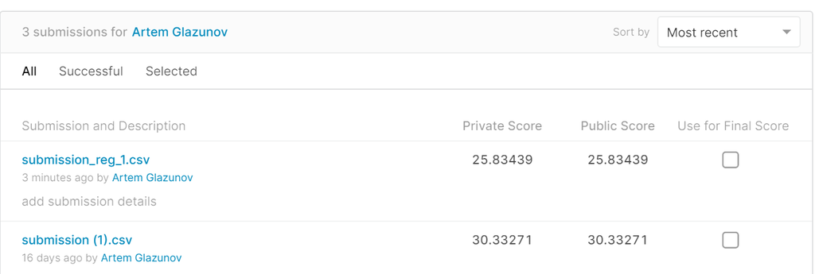

Видно, что есть продвижения. При этом можно заметить, что ошибка на июне больше, чем на мае, что настораживает. Попробуем взять модели, обученные на данных до мая, поскольку в данных за май присутствуют аномалии.

```python
prediction_june2 = pd.DataFrame()
for (ind,(data,model)) in enumerate(zip(data_june,models_may)):
  prediction  = model.predict(data.drop(columns=['target']).values)
  prediction_june2[f'{ind+1}_hours_forecast'] = prediction
```

```python
prediction_june2['zone_id'] = data_june1.zone_id.values
prediction_june2['datetime'] = data_june1.datetime.values
result_june2 = create_submission(prediction_june2)

result_june2.head()
```

|  | y |
| --- | --- |
| 1075_2016-05-31_23_1 | 18.833 |
| 1075_2016-05-31_23_2 | 14.7574 |
| 1075_2016-05-31_23_3 | 7.96659 |
| 1075_2016-05-31_23_4 | 7.30891 |
| 1075_2016-05-31_23_5 | 0.910218 |

```python
result_june2.to_csv('submission_reg_2.csv',index_label='id')
```

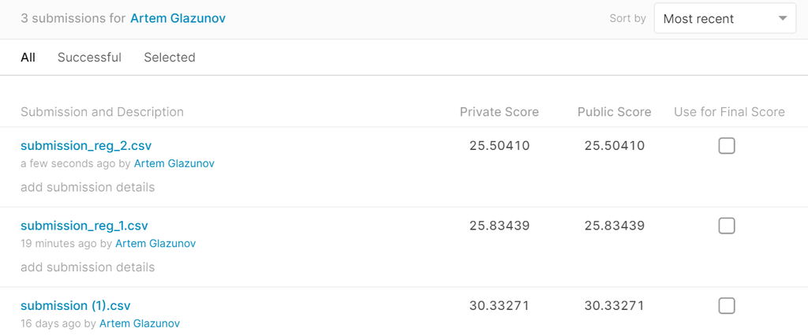

Видно, что ошибка уменьшилась. Теперь запишем предсказания модели для всех имеющихся данных за 7 месяцев, чтобы получить еще один признак для регрессии, который будет использоваться на следующей неделе.

```python
%%time
cols = ['day_hour','history_168','history_24','ts','history_720']
data_1 = prepare_data_to_predict(datasets[0], params_prep = [0,0,2,2,4,23],
                 fill_empty = False,ts_mean_values=None,
                 cols_to_drop=['srmx_forecast'],
                 cols_to_mix_feats = cols ,
                 cols_for_q=[],cols_for_c = [],
                 test_lims = ['2015-12-01 00:00:00','2016-07-01 00:00:00'],
                 verbose=False,
                 )

gc.collect()

cols = ['srmx_forecast','day_hour','ts','ts_shift_1_hours','ts_shift_2_hours','ts_shift_4_hours','history_168']


data_2 = prepare_data_to_predict(datasets[1], params_prep = [2,0,4,2,2,23],
                 fill_empty = False,ts_mean_values=None,
                 cols_to_drop=[],
                 cols_to_mix_feats = cols ,
                 cols_for_q=[],cols_for_c = [],
                 test_lims = ['2015-12-01 00:00:00','2016-07-01 00:00:00'],
                 verbose=False,
                 )

gc.collect()

data_3 = prepare_data_to_predict(datasets[2], params_prep = [2,0,4,2,2,23],
                 fill_empty = False,ts_mean_values=None,
                 cols_to_drop=[],
                 cols_to_mix_feats = cols ,
                 cols_for_q=[],cols_for_c = [],
                 test_lims = ['2015-12-01 00:00:00','2016-07-01 00:00:00'],
                 verbose=False,
                 )

gc.collect()

data_4 = prepare_data_to_predict(datasets[3], params_prep = [2,0,4,2,2,23],
                 fill_empty = False,ts_mean_values=None,
                 cols_to_drop=[],
                 cols_to_mix_feats = cols ,
                 cols_for_q=[],cols_for_c = [],
                 test_lims = ['2015-12-01 00:00:00','2016-07-01 00:00:00'],
                 verbose=False,
                 )

gc.collect()

data_5 = prepare_data_to_predict(datasets[4], params_prep = [2,0,4,2,2,23],
                 fill_empty = False,ts_mean_values=None,
                 cols_to_drop=[],
                 cols_to_mix_feats = cols ,
                 cols_for_q=[],cols_for_c = [],
                 test_lims = ['2015-12-01 00:00:00','2016-07-01 00:00:00'],
                 verbose=False,
                 )

gc.collect()

data_6 = prepare_data_to_predict(datasets[5], params_prep = [2,0,4,2,2,23],
                 fill_empty = False,ts_mean_values=None,
                 cols_to_drop=[],
                 cols_to_mix_feats = cols ,
                 cols_for_q=[],cols_for_c = [],
                 test_lims = ['2015-12-01 00:00:00','2016-07-01 00:00:00'],
                 verbose=False,
                 )

gc.collect()
```

```
CPU times: user 19.8 s, sys: 579 ms, total: 20.3 s
Wall time: 19.9 s
```

```python
%%time
data_7_m = [data_1,data_2,data_3,data_4,data_5,data_6]

prediction_7_m = pd.DataFrame()
for (ind,(data,model)) in enumerate(zip(data_7_m,models_may)):
  prediction  = model.predict(data.drop(columns=['target']).values)
  prediction_7_m[f'{ind+1}_hours_forecast'] = prediction


prediction_7_m.to_csv(os.path.join(PATH_TO_DATA,'prediction_reg_7m.csv'))
```

```
CPU times: user 3min 39s, sys: 2.2 s, total: 3min 41s
Wall time: 3min 41s
```

```python
ddd3=pd.read_csv(os.path.join(PATH_TO_DATA,'prediction_reg_7m.csv'))
ddd3
```

|  | Unnamed: 0 | 1_hours_forecast | 2_hours_forecast | 3_hours_forecast | 4_hours_forecast | 5_hours_forecast | 6_hours_forecast |
| --- | --- | --- | --- | --- | --- | --- | --- |
| 0 | 0 | 9.446603 | 53.461533 | 62.725964 | 50.953915 | 67.012375 | 59.694588 |
| 1 | 1 | 7.852633 | 54.901604 | 64.393750 | 59.313503 | 68.659134 | 62.557373 |
| 2 | 2 | 4.299701 | 59.902157 | 63.465088 | 66.673035 | 66.004620 | 58.885280 |
| 3 | 3 | 3.014358 | 60.974880 | 68.454480 | 67.108380 | 64.249344 | 55.507286 |
| 4 | 4 | 11.664944 | 65.228720 | 73.569430 | 68.153520 | 63.840843 | 56.445190 |
| ... | ... | ... | ... | ... | ... | ... | ... |
| 520807 | 520807 | 18.024553 | 4.196733 | 120.969580 | 109.817345 | 64.195310 | 242.774080 |
| 520808 | 520808 | 13.682662 | 50.272780 | 115.035000 | 100.352350 | 100.783950 | 257.700260 |
| 520809 | 520809 | 11.795953 | 28.722588 | 112.195220 | 124.830124 | 125.333970 | 250.547320 |
| 520810 | 520810 | 19.414177 | 26.127470 | 91.307430 | 131.136860 | 144.680040 | 248.624070 |
| 520811 | 520811 | 18.383997 | 15.805516 | 135.184370 | 162.602890 | 138.048430 | 238.140930 |

520812 rows × 7 columns

- В качестве итога недели, хочу сказать, что решение проводилось с использованием данных только за 3 месяца, при этом ошибка оказалась меньше, чем на всех данных. Предполагаю, что это связано с аномалиями в январе и мае, а также с тем, что зима несколько зашумляет данные для модели для предсказания июня, при этом за основу берется суточная сезонность и недельная сезонность.
- Самыми значимыми признаками стали для 1 модели сам ряд и его производные, а для остальных моделей прогноз, полученный на предыдущей неделе, и его производные.
- Естественно, при использовании данных за год или 2 можно существенно повысить качество, поскольку появятся данные за те же месяцы предыдущих лет, которые позволят модели подстроиться под годовую сезонности и учесть конкретно каждый месяц.